# Introduction to Git and GitHub

# 1 Introduction

Load packages:

```r
library(tidyverse)
```

Resources used to create this lecture:

- https://happygitwithr.com/
- https://edquant.github.io/edh7916/lessons/intro.html
- https://www.codecademy.com/articles/f1-u3-git-setup
- https://medium.com/@lucasmaurer/git-gud-the-working-tree-staging-area-and-local-repo-a1f0f4822018

## 1.1 What and why use Git and GitHub?

[Video](https://www.dropbox.com/s/r4gij79tw8dx1zv/doyle_why_code_git.mp4?dl=0) from Will Doyle, Professor at Vanderbilt University

What is **version control**?

- [Version control](https://git-scm.com/book/en/v2/Getting-Started-About-Version-Control) is a “system that records changes to a file or set of files over time so that you can recall specific versions later”
- Keeps records of changes, who made changes, and when those changes were made
- You or collaborators take “snapshots” of a document at a particular point in time. Later on, you can recover any previous snapshot of the document.

How version control works:

- Imagine you write a simple text file document that gives a recipe for yummy chocolate chip cookies and you save it as `cookies.txt`
- Later on, you make changes to `cookies.txt` (e.g., add alternative baking time for people who like “soft and chewy” cookies)
- When using version control to make these changes, you don’t save entirely new version of `cookies.txt`; rather, you save the changes made relative to the previous version of `cookies.txt`

Why use version control when you can just save new version of document?

1. Saving entirely new document each time a change is made is very inefficient from a memory/storage perspective
   - When you save a new version of a document, much of the contents are the same as the previous version
   - Inefficient to devote space to saving multiple copies of the same content
2. When document undergoes lots of changes – especially a document that multiple people are collaborating on – it’s hard to keep track of so many different documents. Easy to end up with a situation like this:

[figure not shown]

*Credit: Jorge Chan (and also, lifted this example from Benjamin Skinner’s [intro to Git/GitHub lecture](https://edquant.github.io/edh7916/lessons/intro.html))*

What is **Git**? (from git [website](https://git-scm.com/))

> “Git is a free and open source distributed version control system designed to handle everything from small to very large projects with speed and efficiency”
- Git is a particular version control software created by *The Git Project*
- Git can be used by:
  - An individual/standalone developer
  - For collaborative projects, where multiple people collaborate on each file
- The term “**distributed**” means that every user collaborating on the project has access to all files and the history of changes to all files
- Git is the industry standard version control system used to create software
  - For example, [Zoom](https://zoom.us/) is developed on GitHub ([Zoom GitHub site](https://github.com/zoom))
- Increasingly, Git is the industry standard for collaborative academic research projects
  - E.g., the nascent [Unrollment Project](https://github.com/eddatasci/unrollment_proj)
  - Used GitHub to develop research on recruiting by universities at https://emraresearch.org/

What is a **Git repository**?

- A Git repository is any project managed in Git
- From [Git Handbook](https://guides.github.com/introduction/git-handbook/) by github.com:
  - A repository “encompasses the entire collection of files and folders associated with a project, along with each file’s revision history”
  - Because git is a **distributed** version control system, “repositories are self-contained units and anyone who owns a copy of the repository can access the entire codebase and its history”
- This course is a Git repository ([Rclass2 repository](https://github.com/Rucla-ed/rclass2))
- Local vs. remote git repository:
  - **Local** git repository: git repository for a project stored on your machine
  - **Remote** git repository: git repository for a project stored on the internet
- Typically, a local git repository is connected to a remote git repository
  - You can make changes to local repository on your machine and then **push** those changes to the remote repository
  - A collaborator can make changes to their local repository, push them to the remote repository, and then you can **pull** these changes into your local repository

What is **GitHub**?

- [GitHub](https://github.com/) is the industry standard hosting site/service for Git repositories
  - Hosting services allow people/organizations to store files on the internet and make those files available to others
- GitHub stores your local repositories in “the cloud”
  - E.g., if you create a local repository stored on your machine, GitHub enables you to create a “remote” version of this repository
  - Also, you can connect to a remote repository that already exists and create a local version of this respository on your machine
- More broadly, GitHub enables you to store files, share code, and collaborate with others

## 1.2 How we will learn Git and GitHub

> “Whoah, I’ve just read this quick tutorial about git and oh my god it is cool. I feel now super comfortable using it, and I’m not afraid at all to break something.”— said no one ever ([de Wulf](https://www.daolf.com/posts/git-series-part-1/))

Understanding and learning how to use Git and GitHub can be intimidating. A lot of tutorials give you recipes for how to accomplish specific tasks (either point-and-click or issuing commands on command line), but don’t provide a conceptual understanding of how things work.

Here is how we will learn Git and GitHub over the course of the quarter:

- The first of three “units” of the course will be (mostly) devoted to Git and GitHub
- During the Git/GitHub unit, we will:
  - Provide a conceptual overview of concepts and workflow
  - Show you how to accomplish specific tasks by issuing commands on the command line
  - Devote time to providing in-depth conceptual understanding of particular topics/concepts
  - You will practice doing Git/GitHub stuff during in-class exercises and in weekly problem sets
- With the exception of using [github.com](https://github.com/) website for communication (“issues”) and for creating/cloning repositories, we will perform all tasks on the “command line” rather than using a point-and-click graphical user interface (GUI)
  - Initially, this will feel intimidating, but after a few weeks you will see that this helps you understand Git/GitHub better and is much more efficient
- After the Git/GitHub unit:
  - Weekly problem sets will be completed and submitted using GitHub
  - When communicating with your problem set “team,” you will use GitHub “issues”
  - When posing questions to instructors/classmates, you will use GitHub “issues”
  - Selected additional lectures/class exercises about additional Git/GitHub concepts

Organization of `github_lecture.Rmd`, which will be the basis for the Git/GitHub unit:

- Introduction
  - What and why use Git and GitHub?
  - How we will learn Git and GitHub
- Overview of core concepts and work flow
  - Git stores “snapshots,” not “differences”
  - Three components of a Git project
  - Git/GitHub work flow
  - Branch and merge
    - Branches
    - Merges
  - Models for collaborative development
    - Shared repository
    - Fork and pull
- Command line
  - Shell/command line vs. graphical user interface (GUI)
    - Command-line bullshittery
  - Basic (Bash) commands line commands
    - logistics for running `Bash` code in .Rmd code chunks [skip]
    - Bash syntax
    - Changing directories
    - Creating/deleting directories
    - Other commands
- Basic Git tasks
  - Git commands
- Getting started: Git repository
  - Concepts
  - Clone an existing repository to your local machine
  - Create new repository on GitHub and clone to your local machine
  - Create new git repository on your local machine and add to GitHub
- Git: Under the hood
  - git/ directory
  - Git objects
    - Blob object
    - Tree object
    - Commit object
    - Tag object
  - HEAD and refs/
  - Full example
- Git commands: Observing your repository
  - git status
  - git log
  - git diff
- Git commands: Undoing changes
  - git checkout
  - git reset
  - git revert
- Branching
  - git branch
  - git checkout
- Merging
  - git merge
  - Merge conflicts
  - Resolving merge conflicts

# 2 Overview of core concepts and work flow

This section introduces some core concepts and then explains the Git “work flow” (i.e., how Git works)

## 2.1 Git stores “snapshots,” not “differences”

Version control systems that save “differences”

- Prior to Git, “centralized version control systems” were the industry standard version control systems (From [Getting Started - About Version Control](https://git-scm.com/book/en/v2/Getting-Started-About-Version-Control))
  - In these systems, a central server stored all the versions of a file and “clients” (e.g., a programmer working on a project on their local computer) could “check out” files from the central server
- These centralized version control systems stored multiple versions of a file as “differences”
  - For example, imagine you create a simple text file called `twinkle.txt`
  - “Version 1” (the “base” version) of `twinkle.txt` has the following contents:
    - `twinkle, twinkle, little star`
  - You make some changes to `twinkle.txt` and save those changes, resulting in “Version 2,” which has the following contents:
    - `twinkle, twinkle, little star, how I wonder what you are!`
  - When storing “Version 2” of `twinkle.txt`, centralized version control systems don’t store the entire file. Rather, they store the changes relative to the previous version. In our example, “Version 2” stores:
    - `, how I wonder what you are!`
- The below figure portrays version control systems that store data as changes relative to the base version of each file:

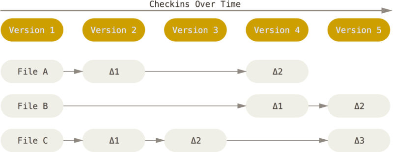

*Credit: [Getting Started - What is Git](https://git-scm.com/book/en/v2/Getting-Started-What-is-Git%3F)*

Git stores data as “snapshots” rather than “differences” (From [Getting Started - What is Git](https://git-scm.com/book/en/v2/Getting-Started-What-is-Git%3F))

- Git doesn’t think of data as differences relative to the base version of each file
- Rather, Git thinks of data as “a series of snapshots of a minature filesystem” or, said differently, a series of snapshots of all files in the repository.
- “With Git, every time you commit, or save the state of your project, Git basically takes a picture of what all your files look like at that moment and stores a reference to that snapshot.”
- “To be efficient, if files have not changed, Git doesn’t store the file again, just a link to the previous identical file it has already stored.”
- The below figure portrays storing data as a stream of snapshots over time:

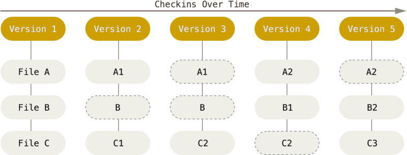

*Credit: [Getting Started - What is Git](https://git-scm.com/book/en/v2/Getting-Started-What-is-Git%3F)*

What is a **commit**?

- A **commit** is a snapshot of all files in the repository at a particular time
- Example: Imagine you are working on a project (repository) that contains a dozen files.
  - You change two files and make a commit
  - Git takes a snapshot of the full repository (all files)
  - Content that remains unchanged relative to the previous commit is stored vis-a-vis a link to the previous commit

## 2.2 Three components of a Git project

- **Local working directory (also called “working tree”)**
  - This is the area where all your work happens! You are writing Rmd files, debugging R-scripts, adding and deleting files
  - These changes are made on your local machine!
- **Git index/staging area**
  - The staging area is the area between your *local working directory* and the *repository*, where you list changes you have made in the local working directory that you would like to commit to the repository
  - Hypothetical work flow (imagine you are working on document `cookies.txt`):
    - Make changes to `cookies.txt` in a text editor. These are changes made in your *local working directory*.
    - Imagine you are happy with some changes you made to `cookies.txt` and you want to *commit* those changes to your repository
    - Before you commit changes to repository, you must *add* them to the *staging area* as an intermediary step
- **Repository**
  - This is the actual repository where Git permanently stores the changes you’ve made in the local working directory and added to the staging area as different versions of the project file
  - Hypothetical work flow to `cookies.txt`:
    - *Add* changes from *local working directory* to *staging area*
    - *Commit* changes from *staging area* to *repository*
  - Each commit to the repository is a different version of the file that represents a snapshot of the file at a particular time
  - Local vs. remote repository
    - When you add a change to the *staging area* and then commit the change to your *repository*, this changes your *local repository* rather than your *remote repository*
    - If you want to change your *remote repository*, you must *push* the change from your *local repository* to your *remote repository*

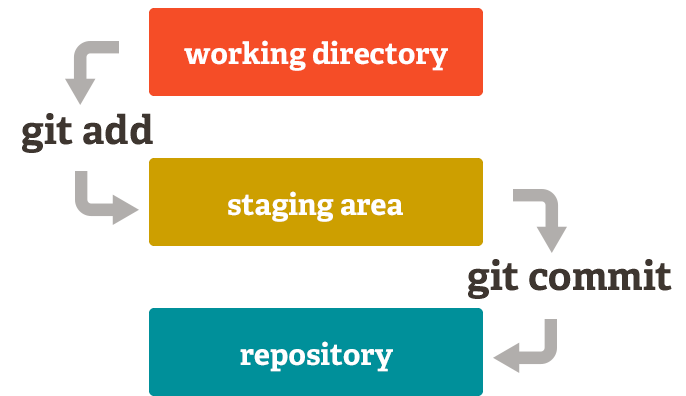

*Credit: Lucas Maurer, medium.com*

## 2.3 Git/GitHub work flow

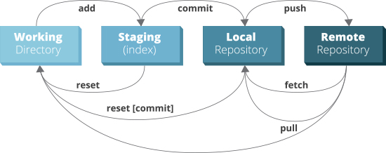

*Credit: Simon Maple, JRebel, https://www.jrebel.com/blog/git-cheat-sheet*

Git commands:

- `add`: Add file from working directory to staging area
- `commit`: Commit file from staging area to local repository
- `push`: Send files from local repository (your machine) to remote repository
  - Synchronizes local repository and remote repository
  - Think of `push` as “uploading”
- `fetch`: Get files from remote repository and put them in local repository
- `pull`: Get files from remote repository and put them in the working directory
  - Think of `pull` as “downloading”
  - `pull` is effectively `fetch` followed by `merge` (discussed later)
- `reset`: After you `add` files from working directory to staging area, `reset` unstages those files

## 2.4 Branch and merge

### 2.4.1 Branches

Why are **branches** necessary? (Drawing from [Using branches](https://backlog.com/git-tutorial/using-branches/) tutorial)

- **Branching** is a means of working on different versions of files in a repository at one time
  - Branching is useful for “solo developer” projects (e.g., a PhD dissertation that does not build on an existing project) but is essential for collaborative projects
- In collaborative projects, it is common for several programmers to share and work on the same programming scripts
- Example in programming/software development world:
  - Imagine your bank is creating a new mobile banking app
  - Some programmers are fixing a bug in how the app imports data from your account
  - Other programmers are developing a new feature (e.g., allowing users to use Venmo to transfer funds)
  - “With so much going on, there needs to be a system in place for managing different versions of the same code base.”
- Example from social science research world:
  - In the [Unrollment Project](https://github.com/eddatasci/unrollment_proj) we are exploring potential bias in alternative algorithms to predict student success
  - We have a file predict_grad.Rmd that reads in secondary data, creates analysis variables, runs alternative models for predicting the probability of obtaining a BA
  - Several collaborators are working on different parts of `predict_grad.Rmd`. For example, one person writing functions to clean data and create analysis variables and another person writing functions to run models and store model results.
  - Need a way for multiple people to work on `predict_grad.Rmd` at the same time

What is a **branch**?

- A branch is an “independent line of development” that “isolates your work from that of other team members” ([Using branches](https://backlog.com/git-tutorial/using-branches/) tutorial)
- By default, a git repository “has one branch named **master** which is considered to be the definitive branch. We use [other] branches to experiment and make edits before committing them to **master**” ([Hello World](https://guides.github.com/activities/hello-world/) tutorial)
- “When you create a branch off the **master** branch, you’re making a copy, or snapshot, of master as it was at that point in time”
- Branches are sometimes described as “deviations” from the master branch
- The below image shows three branches – the master, “Branch 1,” and “Branch 2” – and each circle represents a commit:

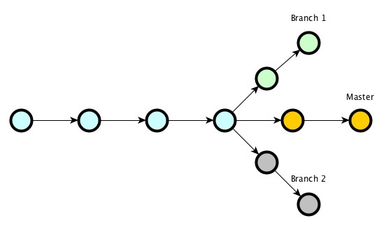

*Credit: [Mastering git branches](https://geeks.uniplaces.com/mastering-branches-in-git-f20cb2d0c51f) by Henrique Mota*

Defining branches in terms of commits:

- People often define a **branch** as “a pointer to a single commit”
  - In programming, a “pointer” is a variable/object that stores the address of other variables or objects in memory
- Recall that a **commit** is a snapshot of a repository at a particular point in time
  - Each commit also stores connections (referred to as “references”) between the current commit and previous commits (referred to as “ancestors”)
- The figure below shows the relationship between commits, references, and branches
- Below, commits 1, 2, 3, and 4 are made to the **master** branch, prior to the creation of “branch 1”
  - When we make “commit 2,” we create “reference 1,” which is a pointer from “commit 2” to “commit 1”
- “commit 4” is the last commit made to the master branch prior to the creation of “branch 1”
- We can think of “branch 1” as a pointer to “commit 4”
- When we make additional commits to “branch 1” (e.g., “commit 5,” “commit 7”) we also create references to the previous commit
  - For example, “commit 5” creates “reference 4,” which is a pointer from “commit 5” to “commit 4”

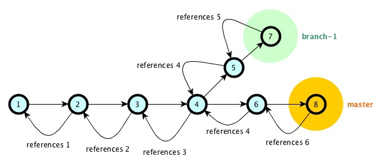

*Credit: [Mastering git branches](https://geeks.uniplaces.com/mastering-branches-in-git-f20cb2d0c51f) by Henrique Mota*

### 2.4.2 Merges

The goal of a **merge** is to “integrate changes from multiple branches into one [branch]” ([An introduction to Git merge and rebase](https://www.freecodecamp.org/news/an-introduction-to-git-merge-and-rebase-what-they-are-and-how-to-use-them-131b863785f/))

The below image shows a merge between the **master** branch and a branch named “develop”

- Each circle represents a commit
- The “develop” branch was created after “commit 2” on the **master**
- After two commits, the “develop” branch is merged back into the **master**

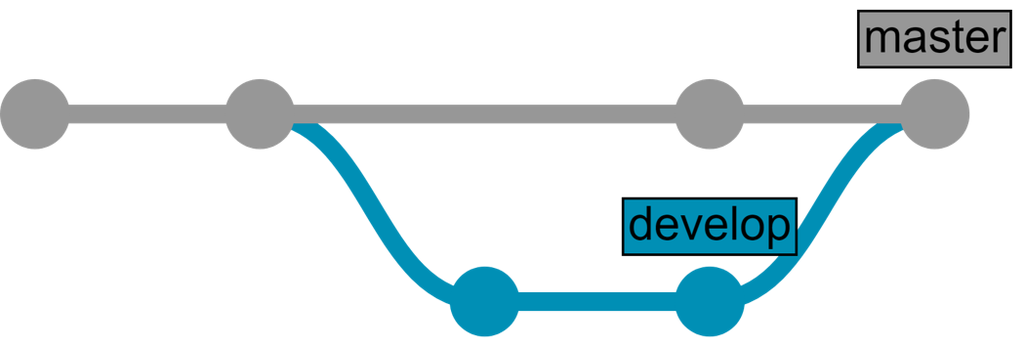

*Credit: [Eduard Lebedyuk](https://community.intersystems.com/post/continuous-delivery-your-intersystems-solution-using-gitlab-part-i-git)*

Merge terminology:

- “Current branch”
  - Branch you are currently working with
  - The branch will be updated/modified by the merge with the “target branch”
  - In the figure above, the **master** branch is the “current branch”
- “Target branch”
  - Branch that will be merged into the “current branch”
  - Target branch will be unaffected by the merge
  - Often, programmers delete the target branch after merging with the current branch
  - In the figure above, “develop” is the target branch

How programmers use branches and merges in day-to-day work:

- Typically, programmers do all work on branches rather than the **master** branch
  - For example, in the [Unrollment Project](https://github.com/eddatasci/unrollment_proj), project co-founders [Will Doyle](https://github.com/wdoyle42) and [Ben Skinner](https://github.com/btskinner) stated that all project work should be done on branches rather than the master
- Branches are created for specific tasks (e.g., fixing a bug, adding a new feature)
  - “Short-lived topic branches, in particular, keep teams focused” ([Git Handbook](https://guides.github.com/introduction/git-handbook/))
  - Once the specific task is completed, the topic branch is merged into the **master** branch and then the topic branch is often deleted

## 2.5 Models for collaborative development

Two primary ways people collaborate on GitHub:

1. Shared repository
2. Fork and pull

### 2.5.1 Shared repository

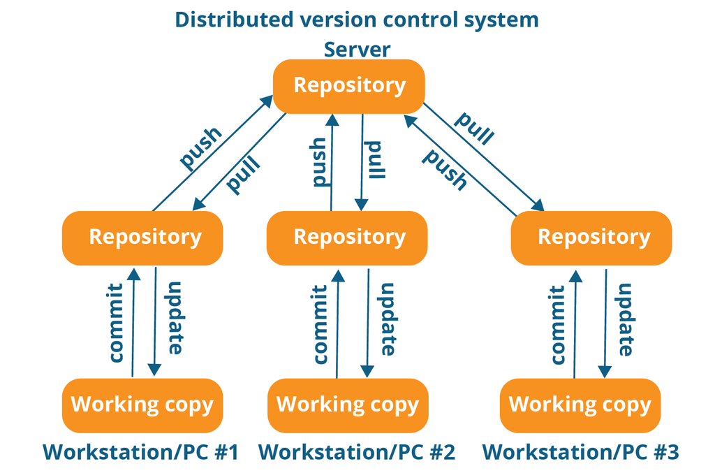

*Credit: [Matuesz Lubanski](https://medium.com/faun/centralized-vs-distributed-version-control-systems-a135091299f0)*

Overview of “shared repository” work flow:

- All work on project happens in a single repository
- Everyone working on the project `clones` the repository to their local computer
- Designate level of “access” for each team member
  - Read access
  - Write access
  - Administrator access
- As an individual team member, you work on specific tasks (e.g., fix a bug, add a new feature, write a lecture on a topic)
  - Work on tasks in your local working directory on your local machine
    - Often, work on tasks in a branch other than **master**
  - Once you complete a task, `commit` changes to your local repository
  - `push` changes from local repository on your machine to remote repository shared with collaborators
- Other team members also working on specific tasks that they `commit` to their local repository and then `push` to the remote repository
  - After your team members `push` a change to remote respository, you may `pull` those changes to your local repository and local working directory
- Issuing a “pull request”
  - For most collaborative projects, users do not simply `push` their changes to the master branch of the shared remote repository
  - Why? Before pushing final changes to shared repository, those changes should be reviewed by other team members. This can be done by issuing a “pull request.”
  - A “pull request” is an announcement to team members that you have made changes and you want those changes to be reviewed before they become final (e.g., merged to the master branch)
    - “If you send a pull request to another repository, you ask their maintainers to pull your changes into theirs (you more or less ask them to use a git pull from your repository)” ([Stack Overflow](https://stackoverflow.com/questions/44669519/difference-between-git-pull-and-git-request-pull))
  - Once you issue a pull request, “the person or team reviewing your changes may have questions or comments. Perhaps the coding style doesn’t match project guidelines, the change is missing unit tests, or maybe everything looks great and props are in order” ([Understanding the GitHub flow](https://guides.github.com/introduction/flow/))
  - We will devote more time to understanding and doing “pull requests” later

### 2.5.2 Fork and pull

What is a **fork**?

- A fork is a copy of a repository that is associated with an individual’s personal account
- The individual has full control of their fork (read, write, administrator)

Why use forks?

- For projects with many contributors, it can become overwhelming to manage the project and to manage individual permissions using the “shared repository” model

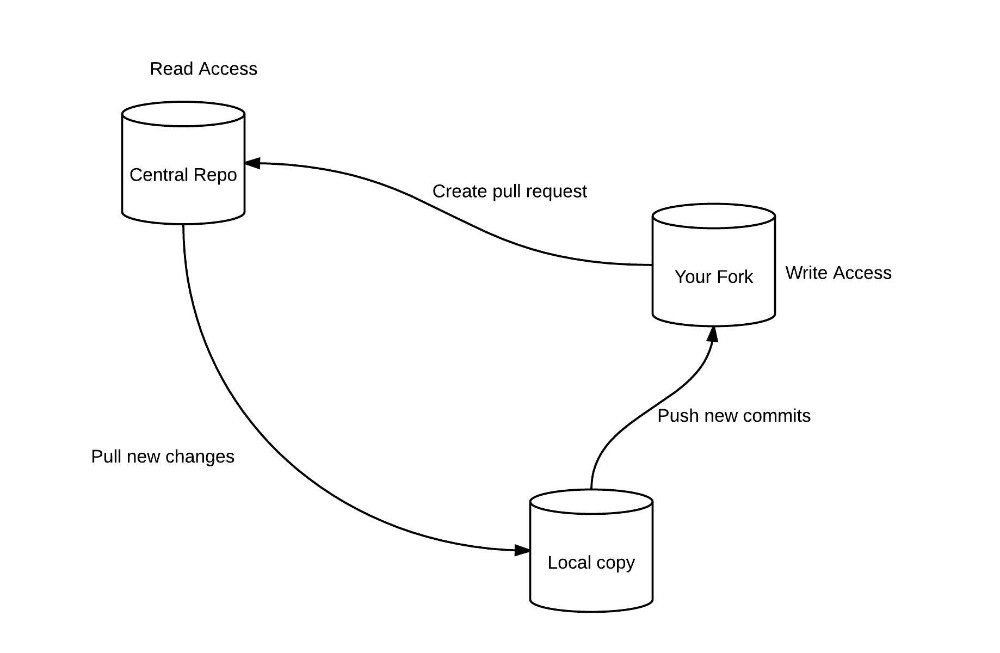

*Credit: [Shaumik Daityari](https://www.sitepoint.com/quick-tip-synch-a-github-fork-via-the-command-line/)*

Overview of “fork and pull” work flow:

- Create a fork repository (copy of project repository associated with your personal account) of the `central_repo` repository
  - Let’s call the forked repository `your_fork`
  - Initially, `your_fork` repository only exists on GitHub
- `clone` the `your_fork` repository to your local machine
- On the local “working directory,” make changes to files
- When you are happy with changes you have made:
  - `add` changes to index/staging area
  - `commit` changes to local `your_fork` repository
  - `push` changes to remote `your_fork` repository
- Issue a “pull request” asking that the changes you have made to remote `your_fork` repository be incorporated to the main `central_repo` repository

# 3 Command line

## 3.1 Shell/command line vs. graphical user interface (GUI)

What is a **shell**?

- “A shell is a terminal application used to interface with an operating system through written commands” ([Git Bash tutorial](https://www.atlassian.com/git/tutorials/git-bash))
- “The shell is a program on your computer whose job is to run other programs. Pseudo-synonyms are ‘terminal’, ‘command line’, and ‘console.’” ([Happy Git and GitHub for the useR](https://happygitwithr.com/shell.html) by Jenny Bryan)
- In this course, we will usually use the term “command line” rather than “shell”
- In the command line, you issue commands one line at a time
- Most programmers use the command line rather than a graphical user interface (GUI) to accomplish tasks

What is **graphical user interface (GUI)**?

- A graphical user interface is an interface for using a program that includes graphical elements such as windows, icons, and buttons that the user can click on using the mouse
- For example, “RStudio” has GUI capabilities in that it has windows and you can perform operations using point-and-click (however, RStudio also has command line capabilities)
- RStudio also includes a GUI interface for performing Git operations
- There are many other GUI software packages for performing GIT operations
  - Popular tools include “GitHub Desktop,” “GitKraken,” and “SmartGit”
  - See [GUI Clients](https://git-scm.com/downloads/guis)

In this course, we will perform Git operations solely using the command line. Why?

- Learning Git from the command line will give you a deeper understanding of how Git and GitHub work
  - I have found that performing Git operations using a GUI did nothing to help me overcome my feelings of anxiety/intimidation about Git
  - As soon as I started doing stuff on the command line, I started feeling less intimidated
- After you start feeling more comfortable with the command line, using the command line makes you *much* more efficient than using a GUI
- Learning the command line takes time and does feel intimidating
  - So we will devote substantial time in-class and during problem sets to learning/practicing the command line

We will use the Unix shell called “Bash” to perform Git operations:

- Some background on “Bash”
  - Unix is an operating system developed by AT&T Bell Labs in the late 1960s
  - The “Unix shell” is a command line program for issuing commands to “Unix-like” operating systems ([Unix Shell](https://en.wikipedia.org/wiki/Unix_shell))
    - Unix-like operating systems include macOS and Linux, but not Windows
    - The first Unix shell was the “Thompson shell” originally written by Ken Thompson at Bell Labs in 1971
  - The Bourne shell was a Unix shell programming language written by Stephen Bourne at Bell Labs in 1979
  - The “Bourne Again Shell” - commonly referred to as “Bash” was “written by Brian Fox for the GNU Project as a free software replacement for the Bourne shell,” and first released in 1989
- Relationship between Git and Bash
  - “At its core, Git is a set of command line utility programs that are designed to execute on a Unix style command-line environment” ([GIT Bash](https://www.atlassian.com/git/tutorials/git-bash))
- Mac users
  - “Terminal” is the application that enables you to control your Mac using a command line prompt
  - Terminal runs the Bash shell programming language
  - Therefore, Mac users use “Terminal” to perform Git operations and the commands to perform Git operations utilize the Bash programming language
- Windows users
  - Windows is not a “Unix-like” operating system. Therefore, Bash is not the default command line interface
  - In order for Windows users to use Bash to perform Git operations, you must install the Git Bash program, which is installed as part of “git for Windows” ([install here](https://gitforwindows.org/))
- Because Mac “Terminal” program and the Windows “Git Bash” program both use the Bash command line program, performing Git operations using the command line will be *exactly the same* for both Mac and Windows users!!!

### 3.1.1 Command-line bullshittery

> “What is wonderful about doing applied computer science research in the modern era is that there are thousands of pieces of free software and other computer-based tools that researchers can leverage to create their research software. With the right set of tools, one can be 10x or even 100x more productive than peers who don’t know how to set up those tools.”

> “But this power comes at a great cost: *It takes a tremendous amount of command-line bullshittery to install, set up, and configure all of this wonderful free software*. What I mean by command-line bullshittery is dealing with all of the arcane, obscure, strange bullshit of the command-line paradigm that most of these free tools are built upon….So perhaps what is more important to a researcher than programming ability is adeptness at dealing with command-line bullshittery, since that enables one to become 10x or even 100x more productive than peers by finding, installing, configuring, customizing, and remixing the appropriate pieces of free software.”

*[Helping my students overcome **command-line bullshittery**](http://www.pgbovine.net/command-line-bullshittery.htm) by Philip J. Guo*

## 3.2 Basic (Bash) commands line commands

### 3.2.1 logistics for running `Bash` code in .Rmd code chunks [skip]

Checking that RMarkdown can run `Bash` commands [code not run]:

```r
names(knitr::knit_engines$get())
#knitr::knit_engines$get("bash")

# should exist
Sys.which('bash')
Sys.which('python')

#path of where executables are run
Sys.getenv("PATH")
Sys.getenv("HOME")

#if path to an executable must be added to PATH
  #old_path <- Sys.getenv("PATH")
  #old_path
  #Sys.setenv(PATH = paste(old_path, "C:\\Users\\ozanj\\AppData\\Local\\Programs\\Python\\Python38", sep = ";"))
  #Sys.getenv("PATH")
```

Show “home” directory for code chunks

```r
Sys.getenv("HOME")
```

```
## [1] "/Users/cyouh95"
```

Show “home” directory for `bash` code chunks

```bash
cd ~
pwd
```

```
## /Users/cyouh95
```

note: home directory for r code chunks run in R might be different

```r
setwd("~")
getwd()
```

```
## [1] "/Users/cyouh95"
```

### 3.2.2 Bash syntax

We can run Bash code instead of R code by replacing `{r}` with `{bash}` at top of chunk.

- Note that the default working directory when you run a code chunk in a .Rmd file is the directory where the .Rmd file is saved
  - This is true for an R code chunk, a Bash code chunk, or any other programming language
  - If you change working directories within a code chunk, the working directory reverts back to where the .Rmd file is saved after the code chunk finishes running

```bash
pwd
ls
```

```
## /Users/cyouh95/Projects/RStudio/rclass2/lectures/github
## git_lecture.Rmd
## git_lecture.html
## git_lecture.md
## github_lecture.Rmd
## github_lecture.html
## github_lecture.md
## render_toc.R
## text
```

We can see the help file for any Bash command by typing:

- `command_name --help` (Windows) or `man command_name` (Mac)
- For example:

```bash
ls --help
man ls
```

Let’s learn a bit about Bash command syntax.

The Bash command `ls` lists the contents (e.g., files, folders) of a directory. A “directory” is another word for “folder.” In Terminal/Git Bash, try typing `ls` and then hit `ENTER` key.

The `pwd` command shows the filepath of the directory you are currently in, that is the current working directory. In Terminal/Git Bash, try typing `pwd` and then hit `ENTER` key.

Note that you can also run Bash code from within an R code chunk of a .Rmd file. First, let’s run some simple R commands from within an R code chunk:

```r
library(tidyverse)
mpg %>% head(5)
```

```
## # A tibble: 5 x 11
##   manufacturer model displ  year   cyl trans  drv     cty   hwy fl    class
##   <chr>        <chr> <dbl> <int> <int> <chr>  <chr> <int> <int> <chr> <chr>
## 1 audi         a4      1.8  1999     4 auto(… f        18    29 p     comp…
## 2 audi         a4      1.8  1999     4 manua… f        21    29 p     comp…
## 3 audi         a4      2    2008     4 manua… f        20    31 p     comp…
## 4 audi         a4      2    2008     4 auto(… f        21    30 p     comp…
## 5 audi         a4      2.8  1999     6 auto(… f        16    26 p     comp…
```

Syntax of `ls` command:

- `ls [option(s)] [file(s)]`
- The bracketed `[option(s)]` and `[file(s)]` means they are optional and you do not need to specify these
- Options in the `ls` command
  - In the help file for `ls` we see that most options can be specified using `-` or `--`
  - For example, `-a` and `--all` are two different ways to specify the option “do not ignore entries starting with `.`”
  - For the most part, `--` is the way to specify the long name version of an option and `-` is the way to specify the short name version. For more see [blog discussion](https://askubuntu.com/questions/813303/whats-the-difference-between-one-hyphen-and-two-hyphens-in-a-command).

**Example**: Using `ls` command (run in code chunk and run on command line)

- Without options:

```bash
pwd
ls
```

```
## /Users/cyouh95/Projects/RStudio/rclass2/lectures/github
## git_lecture.Rmd
## git_lecture.html
## git_lecture.md
## github_lecture.Rmd
## github_lecture.html
## github_lecture.md
## render_toc.R
## text
```

- Using `-a` to include entries that start with `.`:

```bash
pwd
ls -a
```

```
## /Users/cyouh95/Projects/RStudio/rclass2/lectures/github
## .
## ..
## git_lecture.Rmd
## git_lecture.html
## git_lecture.md
## github_lecture.Rmd
## github_lecture.html
## github_lecture.md
## render_toc.R
## text
```

- Using `--all` to include entries that start with `.`:

```bash
pwd
ls --all
```

### 3.2.3 Changing directories

**`cd` command**: Changes the current directory

- Syntax
  - `cd [option(s)] directory_name`
- Example: Change current directory to the `lectures` directory
  - `cd lectures`
- In Bash, separate sub-folders using `/` rather than `\` [even if you are using a PC!]
- **Absolute** vs. **relative** filepaths
  - Can specify `directory_name` using **absolute** or **relative** filepaths
  - **Absolute** filepath: the complete filepath relative to the “root” directory
    - Example:
      - `cd "/c/Users/ozanj/documents/rclass2/lectures"`
  - **Relative** filepath: filepath relative to the current directory
    - Example [starting from working directory `rclass2`]:
      - `cd lectures`
      - `cd lectures/github`
  - By default, `cd` command assumes you are using a **relative** filepath
- `../` or `..` – move up one directory
  - Example [assume working directory is `"/c/Users/ozanj/documents/rclass2/lectures"`]:
    - `cd ..` – move up one directory to `rclass2`
    - `cd ../problem_sets` – move up one directory to `rclass2` and then change to `problem_sets` directory
- `./` or `.` – current directory
  - Example [assume working directory is `"/c/Users/ozanj/documents/rclass2/lectures"`]:
    - `cd .` – doesn’t change current working directory
    - `cd ./` – doesn’t change current working directory
    - `cd ./ggplot` – changes to directory `lectures/ggplot`
      - Same as `cd ggplot`
- `cd` [by itself] or `cd ~` changes to your “home directory”

**Example**: Using `cd` command

- *Can run these commands in .Rmd code chunk or paste them to Terminal/Git Bash command line*
- **Note**: When running from .Rmd code chunk the working directory is `rclass2/lectures/github`
- Move up one directory level and then show file path and list contents of directory:

```bash
pwd
cd ../
pwd
ls
```

```
## /Users/cyouh95/Projects/RStudio/rclass2/lectures/github
## /Users/cyouh95/Projects/RStudio/rclass2/lectures
## _style
## apa.csl
## ggplot
## github
## rclass2_bib.bib
```

- Move up two directory levels and then show file path and list contents of directory:

```bash
pwd
cd ../../
pwd
ls
```

```
## /Users/cyouh95/Projects/RStudio/rclass2/lectures/github
## /Users/cyouh95/Projects/RStudio/rclass2
## README.md
## _config.yml
## _data
## _layouts
## _resources
## _working
## assets
## lectures
## problem_sets
## rclass2.Rproj
## syllabus
```

- Move up two directory levels and then show file path and list contents of directory, including entries that begin with `.`:

```bash
pwd
cd ../../
pwd
ls -a
```

```
## /Users/cyouh95/Projects/RStudio/rclass2/lectures/github
## /Users/cyouh95/Projects/RStudio/rclass2
## .
## ..
## .DS_Store
## .Rhistory
## .Rproj.user
## .git
## .gitignore
## README.md
## _config.yml
## _data
## _layouts
## _resources
## _working
## assets
## lectures
## problem_sets
## rclass2.Rproj
## syllabus
```

- Move up one directory, then change to `ggplot` directory:

```bash
pwd

cd ../
pwd

cd ggplot
pwd

ls
```

```
## /Users/cyouh95/Projects/RStudio/rclass2/lectures/github
## /Users/cyouh95/Projects/RStudio/rclass2/lectures
## /Users/cyouh95/Projects/RStudio/rclass2/lectures/ggplot
## ggplot_lecture.Rmd
## ggplot_lecture.html
## ggplot_lecture.md
```

### 3.2.4 Creating/deleting directories

**`mkdir` command**: Makes a directory

- Syntax
  - `mkdir [option(s)] directory_name(s)`
- Common option
  - `-p` – no error if existing, make parent directories as needed

**Example**: Using `mkdir` command

- Make new directory:

```bash
cd ../../../
pwd
mkdir mkdir_test
```

- Move to new directory and create sub-folders:

```bash
cd ../../../

cd mkdir_test

mkdir folder_a folder_b folder_c
ls
```

**`rm` command**: Removes a file or directory

- Syntax
  - `rm [option(s)] file/directory_name(s)`
- Common options
  - `-f` – force remove
    - `rm -f some_file.txt`
  - `-r` – delete directory (default is deleting a file)
    - `rm -r some_directory`
  - `-rf` – force remove directory
    - `rm -rf some_directory`

**Example**: Using `rm` command

- Remove directory named `folder_a`:

```bash
cd ../../../

cd mkdir_test

rm -rf folder_a
ls
```

### 3.2.5 Other commands

**`touch` command**: Creates a file

- `touch file_name(s)`

**`cat` command**: Outputs content of a file

- `cat file_name(s)`

**`cp` command**: Copies files

- `cp file1 file2` –- copy file1 to file2
- `cp -r dir1 dir2` -– copy dir1 to dir2; create dir2 if it doesn’t exist

**`mv` command**: Renames or moves files

- `mv file1 file2` – rename file1 to file2
- `mv file/directory_name(s) directory_name` – if last argument provided is a directory, move all previous files and/or directories into the destination directory
  - `mv file1 dir2` – move file1 into dir2
  - `mv dir1 dir2` – move dir1 into dir2
  - `mv dir1/file1 dir2 dir3` – move file1 (originally located inside dir1) and dir2 into dir3

# 4 Basic Git tasks

## 4.1 Git commands

Git command “cheat sheets”:

- https://github.github.com/training-kit/downloads/github-git-cheat-sheet.pdf
- https://www.jrebel.com/blog/git-cheat-sheet

When performing git operations on command line, all commands begin with `git`, for example:

- `git init`
- `git clone url_of_remote_repository`
- `git status`

For an overview of git command syntax and a list of common git commands, type this in command line:

```bash
git --help
```

To see the help file for a particular git command (e.g., `add`, `commit`, `clone`), type `git command_name --help`. For example:

```bash
git add --help

# or this:
# git help add
```

Basic/essential git commands:

- **Create a repository**
  - `git init`
    - “Initializes a brand new Git repository and begins tracking an existing directory. It adds a hidden subfolder [named `.git`] within the existing directory that houses the internal data structure required for version control” ([Git Handbook](https://guides.github.com/introduction/git-handbook/))
  - `git clone url_of_remote_repository`
    - “Creates a local copy of a project that already exists remotely. The clone includes all the project’s files, history, and branches” ([Git Handbook](https://guides.github.com/introduction/git-handbook/))
- **Make a change**
  - `git add file_name(s)`
    - Add file(s) from local working directory to staging area/index
    - Note: You must “stage” changes to a file before you `commit` them to your local repository
  - `git commit -m "commit message"`
    - All changes to files that have been staged [previous step] are committed to the local repository
    - Each commit is a snapshot of all files in your repository
    - Note: `-m` is an option to the `git commit` command, which specifies that you will add a brief description about changes you are committing
- **Observe your repository**
  - `git status`
    - “Shows the status of changes as untracked, modified, or staged” ([Git Handbook](https://guides.github.com/introduction/git-handbook/))
- **Synchronize with remote repository**
  - `git push`
    - “Updates the remote repository with any commits made locally” ([Git Handbook](https://guides.github.com/introduction/git-handbook/))
  - `git pull`
    - Updates the local repository with any commits from the remote repository

# 5 Getting started: Git repository

Basic stuff you will do all the time:

- `clone` an existing remote repository from GitHub to your local machine
  - For example, clone the repository for this class – named `student_lastname` (e.g., `student_jaquette`) – to your local machine
- Create new git repo
  - Approach A: Create new repo on GitHub and clone to your local machine
  - Approach B: Create new repo on your local machine and connect to remote repo on GitHub

## 5.1 Concepts

What are **local** and **remote** repositories?

- Local vs. remote git repository:
  - **Local** git repository: git repository for a project stored on your machine
  - **Remote** git repository: git repository for a project stored on the internet (e.g., GitHub)
- Typically, a local git repository is connected to a remote git repository
  - You can make changes to local repository on your machine and then push those changes to the remote repository
  - A collaborator can make changes to their local repository, push them to the remote repository, and then you can pull these changes into your local repository
- A remote repository is identified by its URL, which can be used to clone the repository or add it as a remote to a local repository
  - There are 2 types of URL: HTTPS and SSH
  - HTTPS and SSH are two different ways to authenticate that you are you
  - If you haven’t set up SSH, then choose HTTPS

**`git remote`**: Show list of connected remote repositories

- Help: `git remote --help`
- Syntax: `git remote [<option(s)>]`
- Options:
  - `-v`: Show more detailed info about the remotes, including its URL

Understanding how local and remote repositories are connected:

- We can use `git remote` to check which remote repository is connected (*i.e., which remote(s) you can push to and pull from*)
  - By convention, the remote repository is named `origin`, but you could call it anything
  - When you clone a repository, it will by default be given the name `origin`, but you could change it afterwards if you wanted to
  - When you add a remote, you could name it anything
- Each local branch can be set to track a remote branch (*e.g., your local **master** branch tracks the remote **master** branch*)
  - The remote branch that you are tracking is known as the **upstream branch**
  - Once the upstream branch is set for a local branch, git will know where to push to and pull from
  - When you clone a repository, your local branch will automatically be set to track the corresponding remote branch
  - When you push a new local branch to the remote, you will need to set the upstream branch the very first time you push

## 5.2 Clone an existing repository to your local machine

**Obtain the URL of the remote repository on GitHub**:

- In your browser, navigate to the repository on GitHub
- Click on the green `Clone or download` button
- Copy either the HTTPS or SSH URL to your clipboard (*ignore the `Open in Desktop` and `Download ZIP` options*)

**Clone the repository to your local machine**:

- In your Terminal/Git Bash, change directory into where you want to clone the repository
  - Note that you do not need to create a new folder for this repository. Cloning it will create a folder for you that contains the contents of the repository.
- Use the `git clone` command to clone the repository to your local machine

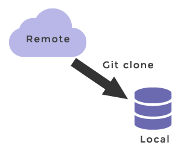

*Credit: [W3 docs, Git clone](https://www.w3docs.com/learn-git/git-clone.html)*

**`git clone`**: Clone a repository into a new directory

- Help: `git clone --help`
- Syntax: `git clone <repo_url>`
  - The `repo_url` can be the HTTPS or SSH URL
- Result:
  - A new directory will be created that contains the cloned repository
  - The remote repository will be given the default name of `origin`
  - Local branches are created that tracks the corresponding remote branches

**Example**: Using `git clone` to clone a repository**

- The repository downloadipeds, created by [Ben Skinner](https://github.com/btskinner), contains a script to “batch download” files from the [Integrated Postsecondary Data System (IPEDS)](https://nces.ed.gov/ipeds/), which contains data on U.S. colleges and universities
- Copy the repository URL and use it to clone the repository to your local machine
  - HTTPS URL will be: `https://github.com/btskinner/downloadipeds.git`
  - SSH URL will be: `git@github.com:btskinner/downloadipeds.git`

```bash
# Change directory to where you want to clone the repository
cd ~

# This will be the directory where the `downloadipeds` repository will be cloned
# Note that you do not need to create a `downloadipeds` sub-directory yourself
pwd
```

```
## /Users/cyouh95
```

```bash
# Clone the remote repository
git clone https://github.com/btskinner/downloadipeds.git  # HTTPS URL
# git clone git@github.com:btskinner/downloadipeds.git  # SSH URL
```

```
## Cloning into 'downloadipeds'...
```

```bash
# Change directory to the newly cloned `downloadipeds`
cd downloadipeds
pwd

# List out contents of repository
ls -la
```

```
## /Users/cyouh95/downloadipeds
## total 72
## drwxr-xr-x    8 cyouh95  staff    272 Apr 12 23:11 .
## drwxr-xr-x+ 102 cyouh95  staff   3468 Apr 12 23:11 ..
## drwxr-xr-x   12 cyouh95  staff    408 Apr 12 23:11 .git
## -rw-r--r--    1 cyouh95  staff     20 Apr 12 23:11 .gitignore
## -rw-r--r--    1 cyouh95  staff   1073 Apr 12 23:11 LICENSE
## -rw-r--r--    1 cyouh95  staff   4388 Apr 12 23:11 README.md
## -rwxr-xr-x    1 cyouh95  staff   5847 Apr 12 23:11 downloadipeds.R
## -rwxr-xr-x    1 cyouh95  staff  11754 Apr 12 23:11 ipeds_file_list.txt
```

```bash
# List out the connected remote, which is named `origin` by default
git remote
```

```
## origin
```

```bash
# Display more details about the remote, including the repository URL
git remote -v
```

```
## origin   https://github.com/btskinner/downloadipeds.git (fetch)
## origin   https://github.com/btskinner/downloadipeds.git (push)
```

## 5.3 Create new repository on GitHub and clone to your local machine

The repository you clone to your local machine can also be a new repository that you create:

- Create a new repository on [GitHub](https://github.com/new)
- Make sure to check the `Initialize this repository with a README` option
- You will then be able to clone your new repository to your local machine as described in the previous section

## 5.4 Create new git repository on your local machine and add to GitHub

Alternatively, you can create a new git repository on your local machine, and then connect it to the remote on GitHub.

**Create a local git repository**:

- In your Terminal/Git Bash, create a new directory or change into an existing directory that you want to turn into a git repository
- Turn this directory into a git repository using `git init`
- In this directory, you can use any git commands and start tracking files
  - For example, create/change one or more file(s)
  - `git add` changes to file(s) from the “local working directory” to the “staging area”/“index”
  - `git commit` all staged changes to the “local repository”

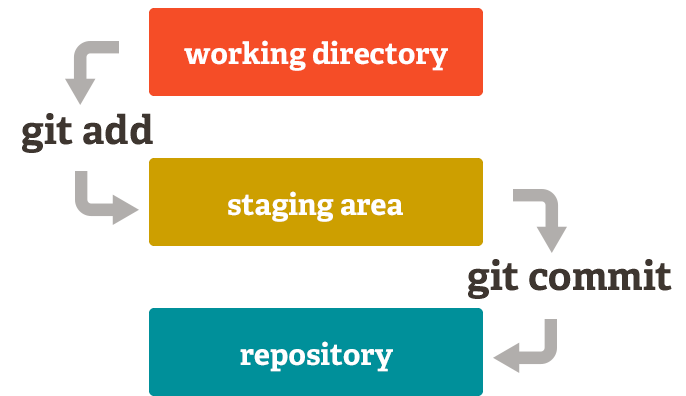

*Credit: Lucas Maurer, medium.com*

**Create a remote repository on GitHub**:

- Create a new repository on [GitHub](https://github.com/new)
- Do **not** check the `Initialize this repository with a README` option
- After creation, you will be able to see the HTTPS/SSH URL of your new repository. Save this URL for later.

**Connect your local repository to the remote**:

- In your Terminal/Git Bash, use `git remote add` to add a new remote for your local repository
  - This will allow you to start pushing to and pulling from the remote repository
- The very first time you push to the remote, you’ll need to use the `--set-upstream` option with the `git push` command
  - All new repositories start off with the default **master** branch
  - If you are pushing a new local branch to the remote for the first time, you need to set the upstream branch so Git knows which remote branch to track
  - For example, we’ll want to set our local **master** branch to track the remote repository’s **master** branch

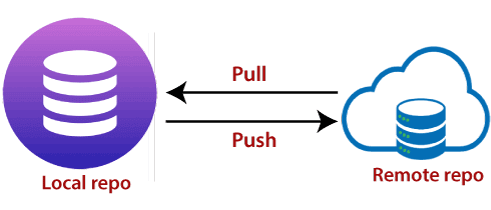

*Credit: [Java T Point, Git Push](https://www.javatpoint.com/git-push)*

**`git remote`**: Add or modify a remote repository

- Help: `git remote --help`
- Syntax:
  - `git remote add <remote_name> <remote_url>`: Add a new remote
    - `remote_name`: Name we choose to call our remote repository, conventionally `origin`
    - `remote_url`: HTTPS/SSH URL of remote repository
  - `git remote set-url <remote_name> <remote_url>`: Update the URL for the specified remote
    - `remote_name`: Name of the remote we want to update URL for
    - `remote_url`: HTTPS/SSH URL we want to update to

**`git push`**: Set and push to upstream branch

- Help: `git push --help`
- Syntax: `git push --set-upstream <remote_name> <branch_name>`
  - `remote_name`: Name of the remote repository to push to
  - `branch_name`: Name of the remote branch you want your current branch to track
- Result:
  - Your current branch will be set to track the specified remote repository’s branch
  - This will only need to be run the first time you push a new local branch to the remote. All subsequent pushes can just be `git push`.

**Example**: Full sample workflow**

```bash
# CREATING AND CHANGING DIRECTORIES

  cd ~ # change directories to home directory

  #cd documents # change to "documents" [if necessary]

  ls # list files in directory

  # make new directory that will be our git repository
    # rm -rf gitr_practice # remove if it exists
  mkdir gitr_practice

  cd gitr_practice # move to new directory

  ls -a # show all files in directory

# INITIALIZING GIT REPOSITORY

  # turn the current, empty directory into a fresh Git repository
  git init

  ls -a # show all files in directory

# CHANGING FILES IN WORKING DIRECTORY

  # create a new README file with some sample text
  echo "Hello. I thought we would be learning R this quarter" >> README.txt

  # view the file README.txt
  cat README.txt

  # create a simple R script
  echo "library(tidyverse)" >> simple_script.r
  echo "mpg %>% head(5)" >> simple_script.r # add another line to simple_script.r

  cat simple_script.r # show contents of file simple_script.r

# STAGE AND COMMIT FILES TO LOCAL REPOSITORY

  # check status of git repository
  git status

  # add README.txt from working directory to staging area (will now become a file that is "tracked" by git)
  git add README.txt

  # add simple_script.r from working directory to staging area (will now become a file that is "tracked" by git)
  git add simple_script.r

  # check status
  git status

  # commit changes to local repository
  git commit -m "Initial commit, README.txt simple_script.r"

  git status

# CONNECT AND PUSH TO REMOTE REPOSITORY

  # provide the path for the repository you created on GitHub in the first step
  #git remote add origin https://github.com/YOUR-USERNAME/YOUR-REPOSITORY.git
  git remote add origin https://github.com/ozanj/gitr_practice.git

  # push changes to GitHub
  git push --set-upstream origin master
```

**Example**: Using `git remote` to add a remote**

```bash
# Initialize a new git repository in `my_git_repo` directory
cd my_git_repo
git init

# Add remote (https://github.com/Rucla-ed/my_git_repo) and name it `origin`
git remote add origin https://github.com/Rucla-ed/my_git_repo.git

# Check remote
git remote -v
```

```
## Initialized empty Git repository in /Users/cyouh95/my_git_repo/.git/
## origin   https://github.com/Rucla-ed/my_git_repo.git (fetch)
## origin   https://github.com/Rucla-ed/my_git_repo.git (push)
```

Note that we could’ve named the remote repository anything - it doesn’t have to be `origin`:

```bash
# Add remote (https://github.com/Rucla-ed/my_git_repo) and name it `my_remote`
git remote add my_remote https://github.com/Rucla-ed/my_git_repo.git

# Check remote
git remote -v
```

```
## my_remote    https://github.com/Rucla-ed/my_git_repo.git (fetch)
## my_remote    https://github.com/Rucla-ed/my_git_repo.git (push)
```

**Example**: Using `git remote` to update URL for a remote**

```bash
# Check remote
git remote -v
```

```
## my_remote    https://github.com/Rucla-ed/my_git_repo.git (fetch)
## my_remote    https://github.com/Rucla-ed/my_git_repo.git (push)
```

```bash
# Change the URL for the remote named `my_remote`
git remote set-url my_remote https://github.com/Rucla-ed/my_git_repo_2.git
```

```bash
# Check remote
git remote -v
```

```
## my_remote    https://github.com/Rucla-ed/my_git_repo_2.git (fetch)
## my_remote    https://github.com/Rucla-ed/my_git_repo_2.git (push)
```

**Example**: Using `git push` to push a new branch**

```bash
# Create new R script
echo "library(tidyverse)" > create_dataset.R
echo "mpg %>% head(5)" >> create_dataset.R

# Add R script and make a commit
git add create_dataset.R
git commit -m "initial commit"
```

```
## [master (root-commit) d1f860b] initial commit
##  1 file changed, 2 insertions(+)
##  create mode 100644 create_dataset.R
```

```bash
# Because this is a new local branch, we get an error if we just use `git push` on the initial push
git push
```

```
## fatal: The current branch master has no upstream branch.
## To push the current branch and set the remote as upstream, use
##
##     git push --set-upstream my_remote master
```

As hinted in the error message, we need to use the `--set-upstream` option to set upstream branch on the initial push for a new local branch:

```bash
# Recall that we are connected to a remote repository we named `my_remote`
git remote -v
```

```
## my_remote    https://github.com/Rucla-ed/my_git_repo_2.git (fetch)
## my_remote    https://github.com/Rucla-ed/my_git_repo_2.git (push)
```

```bash
# We can check status to see that we are currently on the `master` branch
# (Note that because we have yet to set an upstream branch,
# it does not say our master branch is ahead of remote by 1 commit)
git status
```

```
## On branch master
## nothing to commit, working tree clean
```

```bash
# Use the `--set-upstream` option with the remote and branch names to push new local branch
git push --set-upstream my_remote master
```

```
## To https://github.com/Rucla-ed/my_git_repo_2.git
##  * [new branch]      master -> master
## Branch master set up to track remote branch master from my_remote.
```

```bash
# Check status
# (Now that we have set the upstream branch,
# it says our master branch is up-to-date with the remote's master branch)
git status
```

```
## On branch master
## Your branch is up-to-date with 'my_remote/master'.
##
## nothing to commit, working tree clean
```

# 6 Git: Under the hood

## 6.1 .git/ directory

Every git repository that is created using `git init` contains a **`.git/` directory** that “contains all the informations needed for git to work” (From [Git series 1/3: Understanding git for real by exploring the .git directory](https://www.daolf.com/posts/git-series-part-1/)):

```bash
# Initialize a new git repository in `my_git_repo` directory
cd my_git_repo
git init

ls -al
```

```
## Initialized empty Git repository in /Users/cyouh95/my_git_repo/.git/
## total 0
## drwxr-xr-x    3 cyouh95  staff   102 Apr 12 23:11 .
## drwxr-xr-x+ 103 cyouh95  staff  3502 Apr 12 23:11 ..
## drwxr-xr-x    9 cyouh95  staff   306 Apr 12 23:11 .git
```

What’s inside the **`.git/` directory**?

```bash
# List out the contents of the .git/ directory (in tree form)
find .git -print | sed -e 's;[^/]*/;|____;g;s;____|; |;g'
```

```
## .git
## |____config
## |____description
## |____HEAD
## |____hooks
## | |____applypatch-msg.sample
## | |____commit-msg.sample
## | |____post-update.sample
## | |____pre-applypatch.sample
## | |____pre-commit.sample
## | |____pre-push.sample
## | |____pre-rebase.sample
## | |____pre-receive.sample
## | |____prepare-commit-msg.sample
## | |____update.sample
## |____info
## | |____exclude
## |____objects
## | |____info
## | |____pack
## |____refs
## | |____heads
## | |____tags
```

We will be focusing on:

- `objects/`: Directory containing all git objects
- `HEAD`: Reference to the latest commit of the current branch
- `refs/`: Directory containing the hash ID of commit referred to by `HEAD`

We’ll get into git objects starting in the next section, and see an example of `HEAD` and `refs/` in a later section.

## 6.2 Git objects

What is a **git object**?

- “A git repository is actually just a collection of objects, each identified with their own hash.” (From [Deep dive into git: git Objects](https://aboullaite.me/deep-dive-into-git/))
  - A “hash” can be thought of as an unique ID that points to the git object
  - “Git is a simple key-value data store. You put a value into the repository and get a key by which this value can be accessed.” (From [Becoming a Git pro. Part 1: internal Git architecture](https://indepth.dev/becoming-a-git-pro-part-1-internal-git-architecture/))
    - Key = Hash
    - Value = Git object
- Git objects are stored inside the `.git/objects` directory
  - The first 2 characters of its hash will be the name of the sub-directory within `.git/objects` that it is located in
  - The rest of the hash will be the git object filename
- Use the `git cat-file` command can be used to view information about a git object whose hash you specify
- Use the `git hash-object` to compute (show) the hash for a git “blob” object based on the name of associated file

**`git cat-file`**: Provide content or type and size information for repository objects

- Help: `git cat-file -help`
- Syntax: `git cat-file [<option(s)>] <object>`
- Options:
  - `-p`: Pretty-print the contents of `<object>` based on its type
  - `-t`: Instead of the content, show the object type identified by `<object>`
  - `-s`: Instead of the content, show the object size identified by `<object>`

There are 4 types of **git objects** (From [The Git Object Model](http://shafiul.github.io/gitbook/1_the_git_object_model.html))

- Blob
- Tree
- Commit
- Tag

### 6.2.1 Blob object

A **blob** is generally a file which stores data

- For example, this could be an R script
- The file must be added to the *staging area* (i.e., “index”) in order for the blob object to be created
- The hash of the blob object can be seen in the `.git/objects` directory
  - The first 2 characters of the hash is the name of the sub-directory within `.git/objects`
  - The rest of the hash comes from the git object filename
  - But only the first 7 characters of the hash is required to uniquely identify it
- This hash can also be computed from the name of the file for which the blob is to be created by using the `git hash-object` command

```bash
# Create new R script
echo "library(tidyverse)" > create_dataset.R
echo "mpg %>% head(5)" >> create_dataset.R

# Add R script
git add create_dataset.R

# View .git/objects directory
find .git/objects -print | sed -e 's;[^/]*/;|____;g;s;____|; |;g'
```

```
## |____objects
## | |____c1
## | | |____cff389562e8bc123e6691a60352fdf839df113
## | |____info
## | |____pack
```

**`git hash-object`**: Compute hash for a blob object from name of file

- Help: `git hash-object -help`
- Syntax: `git hash-object <file_name>`

We can use `git hash-object` to verify the hash for `create_dataset.R`:

```bash
# Generate blob object hash for R script
git hash-object create_dataset.R
```

```
## c1cff389562e8bc123e6691a60352fdf839df113
```

**Example**: Using `git cat-file` to view blob object content**

```bash
# View content of create_dataset.R
git cat-file -p c1cff38
```

```
## library(tidyverse)
## mpg %>% head(5)
```

**Example**: Using `git cat-file` to view blob object type**

```bash
# View object type for create_dataset.R
git cat-file -t c1cff38
```

```
## blob
```

**Example**: Using `git cat-file` to view blob object size**

```bash
# View object size for create_dataset.R
git cat-file -s c1cff38
```

```
## 35
```

### 6.2.2 Tree object

A **tree** is a directory that contains references to blobs (*files*) or other trees (*sub-directories*)

- Any sub-directories created inside the git repository is a tree object
  - It contains references to any blobs (*files*) or additional trees (*sub-directories*) within it
- The root directory of the git repository is also a tree itself, and contains references to all its content at the point of commit (like a “snapshot”)
- A commit must be made in order for the tree object(s) to be created

```bash
# Create a sub-directory
rm -rf notes
mkdir notes

# Add files to the sub-directory (since git doesn't track empty directories)
echo "This is my first set of notes." > notes/note_1.txt
echo "This is my second set of notes." > notes/note_2.txt

# Add new files
git add .

# View .git/objects directory
find .git/objects -print | sed -e 's;[^/]*/;|____;g;s;____|; |;g'
```

```
## |____objects
## | |____47
## | | |____6fb98775843929ca6c55b16b04752d973b3d2a
## | |____61
## | | |____08458417308ddc15d7390a2f8db50cf65ec399
## | |____c1
## | | |____cff389562e8bc123e6691a60352fdf839df113
## | |____info
## | |____pack
```

As seen, new blob objects are created for `note_1.txt` and `note_2.txt` since the files have been added (but tree objects will not be created until a commit has been made):

```bash
# View content of note_1.txt and note_2.txt
git cat-file -p 476fb98
git cat-file -p 6108458
```

```
## This is my second set of notes.
## This is my first set of notes.
```

After the files have been committed, tree objects will be created for any sub-directories as well as for the root directory of the repository:

```bash
# Make a commit
git commit -m "initial commit"

# View .git/objects directory
find .git/objects -print | sed -e 's;[^/]*/;|____;g;s;____|; |;g'
```

```
## [master (root-commit) 3e6b9db] initial commit
##  3 files changed, 4 insertions(+)
##  create mode 100644 create_dataset.R
##  create mode 100644 notes/note_1.txt
##  create mode 100644 notes/note_2.txt
## |____objects
## | |____3e
## | | |____6b9db22f702b1d8ca361b3be5c9d8dc2883c94
## | |____47
## | | |____6fb98775843929ca6c55b16b04752d973b3d2a
## | |____61
## | | |____08458417308ddc15d7390a2f8db50cf65ec399
## | |____6c
## | | |____f7bbf49af4f9fd5103cf9f0a3fa25226b12336
## | |____c1
## | | |____cff389562e8bc123e6691a60352fdf839df113
## | |____f5
## | | |____9085df29aed7826a89b23af3f67fc3ab96f643
## | |____info
## | |____pack
```

As we now see, the tree objects for the `my_git_repo/` root directory and `notes/` sub-directory exists, and another object has been created for the commit (*more info on that in next section*):

```bash
# View object type for my_git_repo/ and notes/ trees
git cat-file -t f59085d
git cat-file -t 6cf7bbf

# View object type for the commit
git cat-file -t $(git rev-parse --short HEAD)  # git rev-parse retrieves latest commit hash
```

```
## tree
## tree
## commit
```

The content of a tree object is a list of all blobs (*files*) and other trees (*sub-directories*) in the directory. Each list entry follows the format:

```
<permission_code> <object_type> <object_hash> <object_name>
```

**Example**: Using `git cat-file` to view tree object content for `my_git_repo/` root directory**

First, show files in directory using `ls` command with options `al`

```bash
#show files in directory
ls -al
```

```
## total 8
## drwxr-xr-x    5 cyouh95  staff   170 Apr 12 23:11 .
## drwxr-xr-x+ 103 cyouh95  staff  3502 Apr 12 23:11 ..
## drwxr-xr-x   12 cyouh95  staff   408 Apr 12 23:11 .git
## -rw-r--r--    1 cyouh95  staff    35 Apr 12 23:11 create_dataset.R
## drwxr-xr-x    4 cyouh95  staff   136 Apr 12 23:11 notes
```

Second, show contents of tree using `git cat-file`

```bash
#show files in directory
ls -al
echo ""

# View type and content of my_git_repo/ tree object
git cat-file -t f59085d  # type
git cat-file -p f59085d  # content
```

```
## total 8
## drwxr-xr-x    5 cyouh95  staff   170 Apr 12 23:11 .
## drwxr-xr-x+ 103 cyouh95  staff  3502 Apr 12 23:11 ..
## drwxr-xr-x   12 cyouh95  staff   408 Apr 12 23:11 .git
## -rw-r--r--    1 cyouh95  staff    35 Apr 12 23:11 create_dataset.R
## drwxr-xr-x    4 cyouh95  staff   136 Apr 12 23:11 notes
##
## tree
## 100644 blob c1cff389562e8bc123e6691a60352fdf839df113 create_dataset.R
## 040000 tree 6cf7bbf49af4f9fd5103cf9f0a3fa25226b12336 notes
```

- contents of tree object are essentially a list of files in the directory

**Example**: Using `git cat-file` to view tree object content for `notes/` sub-directory**

```bash
# View type and content of notes/ tree object
git cat-file -t 6cf7bbf  # type
git cat-file -p 6cf7bbf  # content
```

```
## tree
## 100644 blob 6108458417308ddc15d7390a2f8db50cf65ec399 note_1.txt
## 100644 blob 476fb98775843929ca6c55b16b04752d973b3d2a note_2.txt
```

### 6.2.3 Commit object

A **commit** object is created after a commit is made that contains information about the commit:

```
tree <tree_hash>
parent <commit_hash>
author <username> <email> <time>
committer <username> <email> <time>

<commit_message>
```

- `tree`: Reference to the root directory tree object (i.e., “snapshot” of repository at the point of commit)
- `parent`: Reference to the parent commit
- Other information about the commit (e.g., `author`, `committer`, `commit_message`)

All commits except for the initial commit will contain a reference to its `parent` commit. So let’s create a second commit:

```bash
# Modify R script
echo "df <- mpg %>% filter(year == 2008)" >> create_dataset.R

# Add R script
git add create_dataset.R

# Make another commit
git commit -m "second commit"

# View .git/objects directory
find .git/objects -print | sed -e 's;[^/]*/;|____;g;s;____|; |;g'
```

```
## [master 08ea6cc] second commit
##  1 file changed, 1 insertion(+)
## |____objects
## | |____08
## | | |____ea6cc51317b08b1c8c1e1a1c9042b2003cb58d
## | |____3e
## | | |____6b9db22f702b1d8ca361b3be5c9d8dc2883c94
## | |____47
## | | |____6fb98775843929ca6c55b16b04752d973b3d2a
## | |____49
## | | |____0ec1c138021b8d5c196c26a2a7b3de69afc2d1
## | |____52
## | | |____4db779f0a3e3b3b353b522285c7da4830e21f1
## | |____61
## | | |____08458417308ddc15d7390a2f8db50cf65ec399
## | |____6c
## | | |____f7bbf49af4f9fd5103cf9f0a3fa25226b12336
## | |____c1
## | | |____cff389562e8bc123e6691a60352fdf839df113
## | |____f5
## | | |____9085df29aed7826a89b23af3f67fc3ab96f643
## | |____info
## | |____pack
```

**Example**: Using `git cat-file` to view commit object content for first commit**

- **Note**: The commit hash will be different each time we run this because it is dependent on the time

```bash
# Retrieve commit hash for first commit
git rev-list HEAD | tail -n 1

# View content of the commit object
git cat-file -p $(git rev-list HEAD | tail -n 1)
```

```
## 3e6b9db22f702b1d8ca361b3be5c9d8dc2883c94
## tree f59085df29aed7826a89b23af3f67fc3ab96f643
## author cyouh95 <25449416+cyouh95@users.noreply.github.com> 1586758316 -0700
## committer cyouh95 <25449416+cyouh95@users.noreply.github.com> 1586758316 -0700
##
## initial commit
```

**Example**: Using `git cat-file` to view commit object content for second commit**

- **Note**: The commit hash will be different each time we run this because it is dependent on the time

```bash
# Retrieve commit hash for lastest commit
git rev-parse HEAD

# View content of the commit object
git cat-file -p $(git rev-parse HEAD)
```

```
## 08ea6cc51317b08b1c8c1e1a1c9042b2003cb58d
## tree 524db779f0a3e3b3b353b522285c7da4830e21f1
## parent 3e6b9db22f702b1d8ca361b3be5c9d8dc2883c94
## author cyouh95 <25449416+cyouh95@users.noreply.github.com> 1586758317 -0700
## committer cyouh95 <25449416+cyouh95@users.noreply.github.com> 1586758317 -0700
##
## second commit
```

### 6.2.4 Tag object

A **tag** object is created after a tag is generated:

```
object <object_hash>
type <object_type>
tag <tag_name>
tagger <username> <email> <time>

<tag_message>
```

- `object`: Reference to the tagged object
- `type`: Object type of the tagged object (usually a `commit`)
- Other information about the tag (e.g., name of `tag`, `tagger`, `tag_message`)

Let’s create a tag for the current commit:

```bash
# Create a tag
git tag -a v1 -m "version 1.0"

# View .git/objects directory
find .git/objects -print | sed -e 's;[^/]*/;|____;g;s;____|; |;g'
```

```
## |____objects
## | |____08
## | | |____ea6cc51317b08b1c8c1e1a1c9042b2003cb58d
## | |____3e
## | | |____6b9db22f702b1d8ca361b3be5c9d8dc2883c94
## | |____47
## | | |____6fb98775843929ca6c55b16b04752d973b3d2a
## | |____49
## | | |____0ec1c138021b8d5c196c26a2a7b3de69afc2d1
## | |____52
## | | |____4db779f0a3e3b3b353b522285c7da4830e21f1
## | |____61
## | | |____08458417308ddc15d7390a2f8db50cf65ec399
## | |____6c
## | | |____f7bbf49af4f9fd5103cf9f0a3fa25226b12336
## | |____92
## | | |____f8e4ba58f0d260306d70863569502cefae11e3
## | |____c1
## | | |____cff389562e8bc123e6691a60352fdf839df113
## | |____f5
## | | |____9085df29aed7826a89b23af3f67fc3ab96f643
## | |____info
## | |____pack
```

**Example**: Using `git cat-file` to view tag object**

```bash
# View content of the tag object
git cat-file -p $(git show-ref -s v1)  # retrieves hash for v1 tag
```

```
## object 08ea6cc51317b08b1c8c1e1a1c9042b2003cb58d
## type commit
## tag v1
## tagger cyouh95 <25449416+cyouh95@users.noreply.github.com> 1586758317 -0700
##
## version 1.0
```

```bash
# The tagged object was the second commit
git log
```

```
## commit 08ea6cc51317b08b1c8c1e1a1c9042b2003cb58d
## Author: cyouh95 <25449416+cyouh95@users.noreply.github.com>
## Date:   Sun Apr 12 23:11:57 2020 -0700
##
##     second commit
##
## commit 3e6b9db22f702b1d8ca361b3be5c9d8dc2883c94
## Author: cyouh95 <25449416+cyouh95@users.noreply.github.com>
## Date:   Sun Apr 12 23:11:56 2020 -0700
##
##     initial commit
```

## 6.3 HEAD and refs/

The `HEAD` file is a pointer to your current (active) branch – specifically, it points to the latest commit of that branch (whose hash ID is stored in the `refs/` directory). Especially when we get to working with multiple branches, the `HEAD` becomes important as it keeps track of which branch you are currently on.

If we output the contents of `HEAD`, we see it contains a reference to the *master* branch:

```bash
# View content of HEAD
cat .git/HEAD
```

```
## ref: refs/heads/master
```

Following that reference, we can find the hash ID of the latest commit located inside the `refs/` directory:

```bash
# View content of refs/heads/master
cat .git/refs/heads/master
```

```
## 08ea6cc51317b08b1c8c1e1a1c9042b2003cb58d
```

We can use `git log` to verify that this is the hash ID of the latest commit:

```bash
# View commit log
git log
```

```
## commit 08ea6cc51317b08b1c8c1e1a1c9042b2003cb58d
## Author: cyouh95 <25449416+cyouh95@users.noreply.github.com>
## Date:   Sun Apr 12 23:11:57 2020 -0700
##
##     second commit
##
## commit 3e6b9db22f702b1d8ca361b3be5c9d8dc2883c94
## Author: cyouh95 <25449416+cyouh95@users.noreply.github.com>
## Date:   Sun Apr 12 23:11:56 2020 -0700
##
##     initial commit
```

## 6.4 Full example

```bash
# Initialize a new git repository in `my_git_repo` directory
cd my_git_repo
git init
```

```
## Initialized empty Git repository in /Users/cyouh95/my_git_repo/.git/
```

```bash
# Create new R script
echo "library(tidyverse)" > create_dataset.R
echo "mpg %>% head(5)" >> create_dataset.R

# R script initially starts off under `Untracked Files`
git status
```

```
## On branch master
##
## No commits yet
##
## Untracked files:
##   (use "git add <file>..." to include in what will be committed)
##
##  create_dataset.R
##
## nothing added to commit but untracked files present (use "git add" to track)
```

```bash
# Add R script
git add create_dataset.R

# R script moves to `Changes to be committed`
git status
```

```
## On branch master
##
## No commits yet
##
## Changes to be committed:
##   (use "git rm --cached <file>..." to unstage)
##
##  new file:   create_dataset.R
```

```bash
# Once R script has been added, a blob object is created for it in the .git/objects directory
find .git/objects -print | sed -e 's;[^/]*/;|____;g;s;____|; |;g'
```

```
## |____objects
## | |____c1
## | | |____cff389562e8bc123e6691a60352fdf839df113
## | |____info
## | |____pack
```

```bash
# We can use `git hash-object` to verify the hash of the blob object
git hash-object create_dataset.R
```

```
## c1cff389562e8bc123e6691a60352fdf839df113
```

```bash
# With this hash, we can view the content of create_dataset.R
git cat-file -p c1cff38
```

```
## library(tidyverse)
## mpg %>% head(5)
```

```bash
# Make a commit
git commit -m "add create_dataset.R"

# The R script is now no longer listed
git status
```

```
## [master (root-commit) 58c2a0b] add create_dataset.R
##  1 file changed, 2 insertions(+)
##  create mode 100644 create_dataset.R
## On branch master
## nothing to commit, working tree clean
```

```bash
# Check the commit history
git log
```

```
## commit 58c2a0bc663a708f8d1e4ff3c2941a0d1d8593e7
## Author: cyouh95 <25449416+cyouh95@users.noreply.github.com>
## Date:   Sun Apr 12 23:11:57 2020 -0700
##
##     add create_dataset.R
```

```bash
# Verify that `HEAD` is indeed pointing to the last commit made, which is our initial commit
cat .git/HEAD
cat .git/refs/heads/master
```

```
## ref: refs/heads/master
## 58c2a0bc663a708f8d1e4ff3c2941a0d1d8593e7
```

```bash
# Further modify R script, which is now a tracked file
echo "df <- mpg %>% filter(year == 2008)" >> create_dataset.R

# R script is now under `Changes not staged for commit`
git status
```

```
## On branch master
## Changes not staged for commit:
##   (use "git add <file>..." to update what will be committed)
##   (use "git checkout -- <file>..." to discard changes in working directory)
##
##  modified:   create_dataset.R
##
## no changes added to commit (use "git add" and/or "git commit -a")
```

```bash
# View what new changes were made to R script
git diff
```

```
## diff --git a/create_dataset.R b/create_dataset.R
## index c1cff38..490ec1c 100644
## --- a/create_dataset.R
## +++ b/create_dataset.R
## @@ -1,2 +1,3 @@
##  library(tidyverse)
##  mpg %>% head(5)
## +df <- mpg %>% filter(year == 2008)
```

```bash
# Add new changes made to R script
git add create_dataset.R

# .git/objects directory now contains blob objects for both versions of R script
# It also contains objects for the commit and root directory tree
find .git/objects -print | sed -e 's;[^/]*/;|____;g;s;____|; |;g'
```

```
## |____objects
## | |____49
## | | |____0ec1c138021b8d5c196c26a2a7b3de69afc2d1
## | |____58
## | | |____c2a0bc663a708f8d1e4ff3c2941a0d1d8593e7
## | |____96
## | | |____6cc780d5994bc8a4ed535484cd7f8268e8e874
## | |____c1
## | | |____cff389562e8bc123e6691a60352fdf839df113
## | |____info
## | |____pack
```

```bash
# We can use `git hash-object` to verify the hash for the new blob object
git hash-object create_dataset.R
```

```
## 490ec1c138021b8d5c196c26a2a7b3de69afc2d1
```

```bash
# With this hash, we can view the content of the modified create_dataset.R
git cat-file -p 490ec1c
```

```
## library(tidyverse)
## mpg %>% head(5)
## df <- mpg %>% filter(year == 2008)
```

```bash
# Make a commit
git commit -m "modify create_dataset.R"
```

```
## [master 5c9206f] modify create_dataset.R
##  1 file changed, 1 insertion(+)
```

```bash
# Check the commit history
git log
```

```
## commit 5c9206f9170d298aef9e5f17d91ac79283fff6fb
## Author: cyouh95 <25449416+cyouh95@users.noreply.github.com>
## Date:   Sun Apr 12 23:11:57 2020 -0700
##
##     modify create_dataset.R
##
## commit 58c2a0bc663a708f8d1e4ff3c2941a0d1d8593e7
## Author: cyouh95 <25449416+cyouh95@users.noreply.github.com>
## Date:   Sun Apr 12 23:11:57 2020 -0700
##
##     add create_dataset.R
```

```bash
# Verify that `HEAD` is pointing to the last commit made, which is now our second commit
cat .git/HEAD
cat .git/refs/heads/master
```

```
## ref: refs/heads/master
## 5c9206f9170d298aef9e5f17d91ac79283fff6fb
```

```bash
# View content of commit object for second commit
git cat-file -p $(git rev-parse HEAD)
```

```
## tree 6de1187f46bbf4d76cafca7c0e5d3d61db6b5a53
## parent 58c2a0bc663a708f8d1e4ff3c2941a0d1d8593e7
## author cyouh95 <25449416+cyouh95@users.noreply.github.com> 1586758317 -0700
## committer cyouh95 <25449416+cyouh95@users.noreply.github.com> 1586758317 -0700
##
## modify create_dataset.R
```

# 7 Git commands: Observing your repository

Below are some common git commands you might use to observe your repository:

- git status
- git log
- git diff

## 7.1 git status

**`git status`**: Shows the working tree status

- Help: `git status -help`
- Syntax: `git status [<option(s)>]`
  - Commonly used without any options, but see help file for possible options
- Output:
  - Information about the branch (e.g., which branch you are on, its status relative to the remote branch)
  - `Changes to be committed`
    - List of files that have been added to the *staging area* using `git add`
    - These can be committed using `git commit`
    - The filenames will be in green
  - `Changes not staged for commit`
    - List of tracked files (i.e., files that have been added using `git add` before) that have since been changed (e.g., modified, deleted) in the *working directory*
    - These can be added to the *staging area* using `git add`
    - The filenames will be in red
  - `Untracked files`
    - List of untracked files (i.e., new files that have never been added using `git add` before)
    - These can be added to the *staging area* using `git add`
    - The filenames will be in red

Below is a sample output of `git status`:

```
On branch master
Your branch is up-to-date with 'origin/master'.

Changes to be committed:
  (use "git reset HEAD <file>..." to unstage)

    new file:   clean_dataset.R

Changes not staged for commit:
  (use "git add <file>..." to update what will be committed)
  (use "git checkout -- <file>..." to discard changes in working directory)

    modified:   create_dataset.R

Untracked files:
  (use "git add <file>..." to include in what will be committed)

    analyze_dataset.R
```

**Example**: Checking `git status` after creating a new file**

- Imagine you have created a new file called `create_dataset.R` in your git repository
- You will initially see the file listed under `Untracked files`

```bash
# Create new R script
echo "library(tidyverse)" > create_dataset.R
echo "mpg %>% head(5)" >> create_dataset.R

git status
```

```
On branch master
Your branch is up-to-date with 'origin/master'.

Untracked files:
  (use "git add <file>..." to include in what will be committed)

    create_dataset.R

nothing added to commit but untracked files present (use "git add" to track)
```

**Example**: Checking `git status` after adding a file**

- After adding `create_dataset.R`, you will see it listed under `Changes to be committed`

```bash
# Add R script
git add create_dataset.R

git status
```

```
On branch master
Your branch is up-to-date with 'origin/master'.

Changes to be committed:
  (use "git reset HEAD <file>..." to unstage)

    new file:   create_dataset.R
```

**Example**: Checking `git status` after making a commit**

- After making a commit, you will notice that the committed file(s) are no longer listed
- If your local repository is connected with a remote, you’ll also see that it says your branch is ahead of the remote by 1 commit

```bash
# Make a commit
git commit -m "add create_dataset.R"

git status
```

```
On branch master
Your branch is ahead of 'origin/master' by 1 commit.
  (use "git push" to publish your local commits)

nothing to commit, working tree clean
```

**Example**: Checking `git status` after modifying a tracked file**

- If you make further modifications to a file that’s being tracked (i.e., a file that’s been added before), you will see it listed under `Changes not staged for commit` (as compared to under `Untracked files` when it’s never been tracked before)

```bash
# Modify create_dataset.R
echo "df <- mpg %>% filter(year == 2008)" >> create_dataset.R

git status
```

```
On branch master
Your branch is ahead of 'origin/master' by 1 commit.
  (use "git push" to publish your local commits)

Changes not staged for commit:
  (use "git add <file>..." to update what will be committed)
  (use "git checkout -- <file>..." to discard changes in working directory)

    modified:   create_dataset.R

no changes added to commit (use "git add" and/or "git commit -a")
```

## 7.2 git log

**`git log`**: Show commit logs

- Help: `git log -help`
- Syntax: `git log [<option(s)>]`
  - Commonly used without any options, but see help file for possible options
- Output: List of commits in reverse chronological order (i.e., newest first)
  - `commit <commit_hash>`: Each commit can be uniquely identified by their hash ID (SHA-1)
    - **Note**: Only the first 7 characters of this hash is needed to uniquely identify it
  - `Author: <username> <email>`: Username and email of the author of the commit
  - `Date: <commit_date>`: Date of the commit
  - `<commit_message>`: Commit message
- **Note**: If the list of commits is long, you will be able to use your up and down arrow keys to scroll through the log. After you are done viewing, you can hit `q` to exit this read mode.

Below is a sample output of `git log`:

```
commit 2e525e4b1c40f6cffb78438285a00cd7eed54ae0 (HEAD -> master)
Author: username <email@example.com>
Date:   Thu Apr 2 23:53:30 2020 -0700

    second commit

commit 8c20a14b99d7a490580045176287b979c93d9cb5
Author: username <email@example.com>
Date:   Wed Apr 1 22:49:52 2020 -0700

    initial commit
```

## 7.3 git diff

**`git diff`**: Show changes between files, commits, etc.

- Help: `git diff --help`
- Syntax:
  - `git diff [<file_name(s)>]`: Show changes made to unstaged files in *working directory* compared to the “index”
    - In other words, these are the changes that would get added to the *staging area* if you `git add` them
    - This only applies to tracked files (i.e., files listed under `Changes not staged for commit` when you check `git status`), since untracked files have no history in the “index” to compare against
    - If no `file_name(s)` specified, `git diff` shows changes made to all tracked, unstaged files
  - `git diff --cached [<file_name(s)>]`: Show changes made to added files in *staging area* compared to the last commit
    - In other words, these are the changes that would be committed if you run `git commit` command
    - If no `file_name(s)` specified, `git diff --cached` shows changes made to all staged files (i.e., files listed under `Changes to be committed` when you check `git status`)
    - If this is the initial commit, then all staged changes are shown
  - `git diff <commit_hash> <commit_hash> [<file_name(s)>]`: Show changes between the two specified commits
    - If no `file_name(s)` specified, `git diff <commit_hash> <commit_hash>` shows changes between all files
- Output: Comparison results for each file being checked by `git diff`
  - Each output starts with `diff --git a/<file_name> b/<file_name>`, which indicates that two versions of `file_name` is being compared
  - This is followed by some information about whether the versions are previously tracked by Git (indicated by `index`) or if a new file is involved (as in the case of `git diff --cached` for an untracked, staged file – see second example below)
  - The line-by-line comparison of the file begins after the part in the output that starts with `@@`
    - A `-` in front of a line indicates that the line has been removed in `b/<file_name>` as compared to `a/<file_name>`
    - A `+` in front of a line indicates that the line has been added in `b/<file_name>` as compared to `a/<file_name>`

Below is a sample output of `git diff`:

```
diff --git a/create_dataset.R b/create_dataset.R
index c1cff38..5ea84e9 100644
--- a/create_dataset.R
+++ b/create_dataset.R
@@ -1,2 +1,2 @@
 library(tidyverse)
-mpg %>% head(5)
+mpg %>% filter(year == 2008)
```

**Example**: Checking `git diff` for an untracked file**

- Imagine you have created a new file called `create_dataset.R` in your git repository
- Because this file has never been added to “index” before, you will not see any ouput to `git diff`

```bash
# Create new R script
echo "library(tidyverse)" > create_dataset.R

git diff  # No output
```

**Example**: Checking `git diff` for a staged file**

- After staging `create_dataset.R`, it will be added to the “index”
- `git diff --cached` can be used to view all staged changes

```bash
# Add R script
git add create_dataset.R

git diff --cached
```

```
diff --git a/create_dataset.R b/create_dataset.R
new file mode 100644
index 0000000..8b151a2
--- /dev/null
+++ b/create_dataset.R
@@ -0,0 +1 @@
+library(tidyverse)
```

**Example**: Checking `git diff` for a modified, tracked file**

- If you make further modifications to a file that’s being tracked (i.e., a file that’s been added before), you can use `git diff` to see changes between the versions in the *working directory* and the *staging area*

```bash
# Modify create_dataset.R
echo "mpg %>% head(5)" >> create_dataset.R

git diff
```

```
diff --git a/create_dataset.R b/create_dataset.R
index 8b151a2..c1cff38 100644
--- a/create_dataset.R
+++ b/create_dataset.R
@@ -1 +1,2 @@
 library(tidyverse)
+mpg %>% head(5)
```

**Example**: Checking `git diff` after committing changes**

- Suppose you commit the staged changes (i.e., the line `library(tidyverse)` in `create_dataset.R`)
- Note that the output of `git diff` (i.e., comparing changes between the *working directory* and “index”) is the same as the previous example, when the changes were just staged and not yet committed

```bash
# Make a commit
git commit -m "add 1st line to create_dataset.R"

git diff
```

```
diff --git a/create_dataset.R b/create_dataset.R
index 8b151a2..c1cff38 100644
--- a/create_dataset.R
+++ b/create_dataset.R
@@ -1 +1,2 @@
 library(tidyverse)
+mpg %>% head(5)
```

**Example**: Checking `git diff` between commits**

- Now suppose we add the new changes made to `create_dataset.R` in the *working directory* (i.e., the line `mpg %>% head(5)`) and make a second commit

```bash
# Add create_dataset.R and make a commit
git add create_dataset.R
git commit -m "add 2nd line to create_dataset.R"

git log
```

```
commit aa89efba9adddf8547b3743ba81a421dd2a28881 (HEAD -> master)
Author: cyouh95 <25449416+cyouh95@users.noreply.github.com>
Date:   Sat Apr 4 03:20:15 2020 -0700

    add 2nd line to create_dataset.R

commit d5c6e0958fb173af04f7e2c5d5fd81457e8ffd0c
Author: cyouh95 <25449416+cyouh95@users.noreply.github.com>
Date:   Sat Apr 4 03:11:38 2020 -0700

    add 1st line to create_dataset.R
```

- We can use `git diff` to check the differences between the two commits by specifying their hash ID’s
- As seen below, the line `mpg %>% head(5)` has been added between the two commits

```bash
git diff d5c6e09 aa89efb
```

```
diff --git a/create_dataset.R b/create_dataset.R
index 8b151a2..c1cff38 100644
--- a/create_dataset.R
+++ b/create_dataset.R
@@ -1 +1,2 @@
 library(tidyverse)
+mpg %>% head(5)
```

- Note that the order we specify the commit hash ID’s in matters
- As seen below, if we specify the ID of second commit and then the first commit, the displayed differences show that the line `mpg %>% head(5)` has been removed between the two commits

```bash
git diff aa89efb d5c6e09
```

```
diff --git a/create_dataset.R b/create_dataset.R
index c1cff38..8b151a2 100644
--- a/create_dataset.R
+++ b/create_dataset.R
@@ -1,2 +1 @@
 library(tidyverse)
-mpg %>% head(5)
```

# 8 Git commands: Undoing changes

Below are some common git commands you might use to undo changes:

- git checkout
- git reset
- git revert

## 8.1 git checkout

**`git checkout`**: Restore working tree files (or switch branches)

- Help: `git checkout -help`
- Syntax: `git checkout [<file_name(s)>]`
- Result: Undo changes made to specified `file_name(s)` in the *working directory*
  - This only applies to tracked, unstaged files (i.e., files listed under `Changes not staged for commit` when you check `git status`)
- **Note**: The `git checkout` command can also be used for switching branches, but that will be covered later

**Example**: Using `git checkout` to discard changes to a tracked, unstaged file**

```bash
# First, create new R script
echo "library(tidyverse)" > create_dataset.R
echo "mpg %>% head(5)" >> create_dataset.R

# Add/commit R script so it is now tracked
git add create_dataset.R
git commit -m "add create_dataset.R"
```

```
## Initialized empty Git repository in /Users/cyouh95/my_git_repo/.git/
## [master (root-commit) ce780b8] add create_dataset.R
##  1 file changed, 2 insertions(+)
##  create mode 100644 create_dataset.R
```

```bash
# View how create_dataset.R looks when it was committed
cat create_dataset.R
```

```
## library(tidyverse)
## mpg %>% head(5)
```

```bash
# Modify R script
echo "df <- mpg %>% filter(year == 2008)" >> create_dataset.R

# View how create_dataset.R looks now
cat create_dataset.R
```

```
## library(tidyverse)
## mpg %>% head(5)
## df <- mpg %>% filter(year == 2008)
```

```bash
# See exact changes that have been made to file since last commit
git diff
```

```
## diff --git a/create_dataset.R b/create_dataset.R
## index c1cff38..490ec1c 100644
## --- a/create_dataset.R
## +++ b/create_dataset.R
## @@ -1,2 +1,3 @@
##  library(tidyverse)
##  mpg %>% head(5)
## +df <- mpg %>% filter(year == 2008)
```

```bash
# Undo those changes using git checkout
git checkout create_dataset.R

# View file after discarding changes
cat create_dataset.R
```

```
## library(tidyverse)
## mpg %>% head(5)
```

## 8.2 git reset

**`git reset`**: Reset current `HEAD` to the specified state

- Help: `git reset -help`
- Syntax:
  - `git reset HEAD <file_name(s)>`: Unstages the specified `file_name(s)` from the *staging area* to the *working directory*
    - This only applies to staged files (i.e., files listed under `Changes to be committed` when you check `git status`) and will move them back under `Changes not staged for commit` or `Untracked files`
    - `HEAD` is a pointer to the latest commit and will restore the *staging area*/“index” to that state
    - Any changes made to the file in the *working directory* are still retained
  - `git reset <commit_hash>`: Undo all commits up to (but not including) the specified `commit_hash`
    - The `HEAD` pointer will be set to the specified commit
    - The undone changes will be retained in the *working directory*

**Example**: Using `git reset` to unstage a file**

```bash
# First, create new R script
echo "library(tidyverse)" > create_dataset.R
echo "mpg %>% head(5)" >> create_dataset.R

# Add/commit R script so it is now tracked
git add create_dataset.R
git commit -m "add create_dataset.R"
```

```
## Initialized empty Git repository in /Users/cyouh95/my_git_repo/.git/
## [master (root-commit) ce780b8] add create_dataset.R
##  1 file changed, 2 insertions(+)
##  create mode 100644 create_dataset.R
```

```bash
# Modify R script
echo "df <- mpg %>% filter(year == 2008)" >> create_dataset.R

# Add new changes to the staging area
git add create_dataset.R

# Check status to verify it has been staged (listed under `Changes to be committed`)
git status
```

```
## On branch master
## Changes to be committed:
##   (use "git reset HEAD <file>..." to unstage)
##
##  modified:   create_dataset.R
```

```bash
# Use git reset to unstage file
git reset HEAD create_dataset.R

# Check status to verify it has been unstaged (listed under `Changes not staged for commit`)
git status
```

```
## Unstaged changes after reset:
## M    create_dataset.R
## On branch master
## Changes not staged for commit:
##   (use "git add <file>..." to update what will be committed)
##   (use "git checkout -- <file>..." to discard changes in working directory)
##
##  modified:   create_dataset.R
##
## no changes added to commit (use "git add" and/or "git commit -a")
```

**Example**: Using `git reset` to undo a commit**

```bash
# First, create new R script
echo "library(tidyverse)" > create_dataset.R

# Add/commit R script
git add create_dataset.R
git commit -m "add 1st line to create_dataset.R"
```

```
## Initialized empty Git repository in /Users/cyouh95/my_git_repo/.git/
## [master (root-commit) 10f3cf5] add 1st line to create_dataset.R
##  1 file changed, 1 insertion(+)
##  create mode 100644 create_dataset.R
```

```bash
# Modify R script
echo "mpg %>% head(5)" >> create_dataset.R

# Add/commit R script
git add create_dataset.R
git commit -m "add 2nd line to create_dataset.R"
```

```
## [master 57c3d41] add 2nd line to create_dataset.R
##  1 file changed, 1 insertion(+)
```

```bash
# View commit log
git log
```

```
## commit 57c3d41f78b83aec7f512b115751a6e06ccf8db6
## Author: cyouh95 <25449416+cyouh95@users.noreply.github.com>
## Date:   Sun Apr 12 23:11:58 2020 -0700
##
##     add 2nd line to create_dataset.R
##
## commit 10f3cf528199f6c4f83d9592c9b29b485fc1f063
## Author: cyouh95 <25449416+cyouh95@users.noreply.github.com>
## Date:   Sun Apr 12 23:11:58 2020 -0700
##
##     add 1st line to create_dataset.R
```

```bash
# Specify the hash ID of the commit to undo up to
git reset $(git rev-list HEAD | tail -n 1)  # this retrieves the first commit hash

# View commit log - the 2nd commit has been removed
git log
```

```
## Unstaged changes after reset:
## M    create_dataset.R
## commit 10f3cf528199f6c4f83d9592c9b29b485fc1f063
## Author: cyouh95 <25449416+cyouh95@users.noreply.github.com>
## Date:   Sun Apr 12 23:11:58 2020 -0700
##
##     add 1st line to create_dataset.R
```

```bash
# Notice that the changes to the file is still retained in the working directory
cat create_dataset.R
```

```
## library(tidyverse)
## mpg %>% head(5)
```

## 8.3 git revert

**`git revert`**: Revert existing commit(s)

- Help: `git revert -help`
- Syntax:
  - `git revert <commit_hash>`: Revert all commits up to and including the specified `commit_hash`
    - The difference between `git revert` and `git reset` is that the former does not completely remove all past commits, but creates a new one that reverts those changes
    - When working in a collaborative project where multiple users are contributing to a remote repository, you may want to use `git revert` so that it does not permenantly erase history
    - When you are working locally and want to undo commits that you have not yet pushed to a remote, then `git reset` may also be an option
    - **Note**: After entering this command, you’ll be given a chance to edit the commit message of the new commit. Just enter `:q` to use the default message.

**Example**: Using `git revert` to revert a commit**

```bash
# First, create new R script
echo "library(tidyverse)" > create_dataset.R

# Add/commit R script
git add create_dataset.R
git commit -m "add 1st line to create_dataset.R"
```

```
## Initialized empty Git repository in /Users/cyouh95/my_git_repo/.git/
## [master (root-commit) 10f3cf5] add 1st line to create_dataset.R
##  1 file changed, 1 insertion(+)
##  create mode 100644 create_dataset.R
```

```bash
# Modify R script
echo "mpg %>% head(5)" >> create_dataset.R

# Add/commit R script
git add create_dataset.R
git commit -m "add 2nd line to create_dataset.R"
```

```
## [master 57c3d41] add 2nd line to create_dataset.R
##  1 file changed, 1 insertion(+)
```

```bash
# View commit log
git log
```

```
## commit 57c3d41f78b83aec7f512b115751a6e06ccf8db6
## Author: cyouh95 <25449416+cyouh95@users.noreply.github.com>
## Date:   Sun Apr 12 23:11:58 2020 -0700
##
##     add 2nd line to create_dataset.R
##
## commit 10f3cf528199f6c4f83d9592c9b29b485fc1f063
## Author: cyouh95 <25449416+cyouh95@users.noreply.github.com>
## Date:   Sun Apr 12 23:11:58 2020 -0700
##
##     add 1st line to create_dataset.R
```

```bash
# Specify the hash ID of the unwanted commit
git revert $(git rev-parse --short HEAD)  # git rev-parse retrieves latest commit hash

# View commit log
git log
```

```
## [master 2cc1d75] Revert "add 2nd line to create_dataset.R"
##  1 file changed, 1 deletion(-)
## commit 2cc1d75bb41eb6c5759b863455ce91745ff717f4
## Author: cyouh95 <25449416+cyouh95@users.noreply.github.com>
## Date:   Sun Apr 12 23:11:58 2020 -0700
##
##     Revert "add 2nd line to create_dataset.R"
##
##     This reverts commit 57c3d41f78b83aec7f512b115751a6e06ccf8db6.
##
## commit 57c3d41f78b83aec7f512b115751a6e06ccf8db6
## Author: cyouh95 <25449416+cyouh95@users.noreply.github.com>
## Date:   Sun Apr 12 23:11:58 2020 -0700
##
##     add 2nd line to create_dataset.R
##
## commit 10f3cf528199f6c4f83d9592c9b29b485fc1f063
## Author: cyouh95 <25449416+cyouh95@users.noreply.github.com>
## Date:   Sun Apr 12 23:11:58 2020 -0700
##
##     add 1st line to create_dataset.R
```

```bash
# The file now only contains the 1st line
cat create_dataset.R
```

```
## library(tidyverse)
```

# 9 Branching

What is a **branch**?

- A branch is an “independent line of development” that “isolates your work from that of other team members” ([Using branches](https://backlog.com/git-tutorial/using-branches/) tutorial)
- By default, a git repository “has one branch named **master** which is considered to be the definitive branch. We use [other] branches to experiment and make edits before committing them to **master**” ([Hello World](https://guides.github.com/activities/hello-world/) tutorial)
- “When you create a branch off the **master** branch, you’re making a copy, or snapshot, of master as it was at that point in time”
- A branch can be thought of as a “pointer to a single commit”

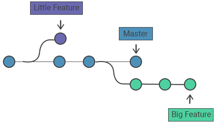

*Credit: [W3 docs, Git branch](https://www.w3docs.com/learn-git/git-branch.html)*

Why use branches?

- Branching is a means of working on different versions of files in a repository at one time
- Typically, there is one main branch (usually **master**) that contains working or approved changes. All other development and testing is usually done on separate branches.
- It is good practice to work on branches, then merge back to master at key points

## 9.1 git branch

**`git branch`**: List, create, or delete branches

- Help: `git branch -help`
- Syntax:
  - `git branch [<option(s)>]`: List existing branches (default: only local branches)
    - There will be a `*` next to your current branch
    - Options:
      - `-a`: List all branches, both local and remote
      - `-v`: Display details about latest commits next to each branch
  - `git branch <branch_name>`: Create new local branch
  - `git branch -d <branch_name>`: Delete local branch
    - You must be on a branch different than the one you want to delete

**Example**: Using `git branch` to list branches**

```bash
# Initialize a new git repository in `my_git_repo` directory
cd my_git_repo
git init

# Note that you won't be able to list branches until you've made at least 1 commit
git branch
```

```
## Initialized empty Git repository in /Users/cyouh95/my_git_repo/.git/
```

```bash
# Create new R script
echo "library(tidyverse)" > create_dataset.R

# Add/commit R script
git add create_dataset.R
git commit -m "import tidyverse in create_dataset.R"
```

```
## [master (root-commit) 2608230] import tidyverse in create_dataset.R
##  1 file changed, 1 insertion(+)
##  create mode 100644 create_dataset.R
```

```bash
# Now we can see the `master` branch listed, with an `*` indicating it is our current branch
git branch
```

```
## * master
```

```bash
# See detailed branch listing with info about the latest commit
git branch -v
```

```
## * master 2608230 import tidyverse in create_dataset.R
```

```bash
# If the repository is connected to a remote, the `-a` option will list remote branches too
# (In the specific example below, the remote is named `origin`)
git branch -a
```

```
## * master
##   remotes/origin/HEAD -> origin/master
```

**Example**: Using `git branch` to create new branch**

```bash
# See branch listing
git branch
```

```
## * master
```

```bash
# Create new branch
git branch dev
```

```bash
# See branch listing
git branch
```

```
##   dev
## * master
```

**Example**: Using `git branch` to delete branch**

```bash
# See branch listing
git branch
```

```
##   dev
## * master
```

```bash
# Delete branch
git branch -d dev
```

```
## Deleted branch dev (was 2608230).
```

```bash
# See branch listing
git branch
```

```
## * master
```

## 9.2 git checkout

**`git checkout`**: Switch branches

- Help: `git checkout -help`
- Syntax:
  - `git checkout <branch_name>`: Switches to an existing branch named `branch_name`
  - `git checkout -b <branch_name>`: Creates a new branch named `branch_name` and switches to it

**Example**: Using `git checkout` to create a new branch and switch to it**

```bash
# See branch listing
git branch
```

```
## * master
```

```bash
# Create new branch and switch to it
git checkout -b dev
```

```
## Switched to a new branch 'dev'
```

```bash
# See branch listing
git branch
```

```
## * dev
##   master
```

**Example**: Using `git checkout` to switch to an existing branch**

```bash
# See branch listing
git branch
```

```
## * dev
##   master
```

```bash
# Switch to an existing branch
git checkout master
```

```
## Switched to branch 'master'
```

```bash
# See branch listing
git branch
```

```
##   dev
## * master
```

# 10 Merging

What is a **merge**?

- The goal of a merge is to “integrate changes from multiple branches into one [branch]” ([An introduction to Git merge and rebase](https://www.freecodecamp.org/news/an-introduction-to-git-merge-and-rebase-what-they-are-and-how-to-use-them-131b863785f/))
- Changes from a “target branch” can be merged into your “current branch”
- It is good practice to make changes on separate branches, then once they look good, merge them back into the main branch (typically **master**)

Types of merges:

- **Fast-forward merge**
  - If after branching, changes are only made to the “target branch,” then merging changes from the “target branch” back to the “current branch” will be a fast-forward merge
  - In other words, the “current branch” will gain all the new changes from “target branch” after the merge, and essentially “fast forward” its `HEAD` to point to the most recent commit from the “target branch”
- **3-way merge**
  - If after branching, changes are made to both the “target branch” and “current branch” (i.e., the branches have *diverged*), then Git will attempt to combine all changes in a 3-way merge
  - The 3-way merge looks at the latest commits on both branches and their common ancestor, then attempts to create a new commit merge that combines all changes
  - Git is able to combine changes made to the same file if the changes are not made to the same line
  - Otherwise, a **merge conflict** occurs and would have to be resolved manually

[figure not shown]

*Credit: [Atlassian, Git merge](https://www.atlassian.com/git/tutorials/using-branches/git-merge)*

## 10.1 git merge

**`git merge`**: Merge branches

- Help: `git merge -help`
- Syntax:
  - `git merge <branch_name>`: All changes from `branch_name` will be merged into the current branch
  - `git merge --abort`: If a conflict arises during the merge, this can be run to restore both branches to their original states

**Example**: Using `git merge` for fast-forward merge**

Continuing from previous examples, we have the `master` and `dev` branches, which are even with the same initial commit:

```bash
# View commit log for `master` branch
git log
```

```
## commit 2608230a883747936bfdb9c7b819de298fcda19d
## Author: cyouh95 <25449416+cyouh95@users.noreply.github.com>
## Date:   Sun Apr 12 23:11:59 2020 -0700
##
##     import tidyverse in create_dataset.R
```

```bash
# Switch to `dev` branch
git checkout dev

# View commit log for `dev` branch
git log
```

```
## Switched to branch 'dev'
## commit 2608230a883747936bfdb9c7b819de298fcda19d
## Author: cyouh95 <25449416+cyouh95@users.noreply.github.com>
## Date:   Sun Apr 12 23:11:59 2020 -0700
##
##     import tidyverse in create_dataset.R
```

```bash
# View content of R script, which is the same on both `master` and `dev` branches
cat create_dataset.R
```

```
## library(tidyverse)
```

Now, let’s make a second commit on the `dev` branch:

```bash
# Modify R script
echo "mpg %>% head(5)" >> create_dataset.R
echo "df <- mpg %>% filter(year == 2008)" >> create_dataset.R

# Add/commit R script
git add create_dataset.R
git commit -m "manipulate mpg dataset"
```

```
## [dev ff0f95d] manipulate mpg dataset
##  1 file changed, 2 insertions(+)
```

```bash
# View commit log for `dev` branch
git log
```

```
## commit ff0f95d50ae73c57a31ee5e413046681415b8b36
## Author: cyouh95 <25449416+cyouh95@users.noreply.github.com>
## Date:   Sun Apr 12 23:11:59 2020 -0700
##
##     manipulate mpg dataset
##
## commit 2608230a883747936bfdb9c7b819de298fcda19d
## Author: cyouh95 <25449416+cyouh95@users.noreply.github.com>
## Date:   Sun Apr 12 23:11:59 2020 -0700
##
##     import tidyverse in create_dataset.R
```

Let’s switch back to the `master` branch and merge in `dev`. Since the `dev` branch is ahead of `master` by 1 commit, the changes can be combined using a fast-forward merge:

```bash
# Switch to `master` branch
git checkout master

# Merge `dev` branch into `master`
git merge dev
```

```
## Switched to branch 'master'
## Updating 2608230..ff0f95d
## Fast-forward
##  create_dataset.R | 2 ++
##  1 file changed, 2 insertions(+)
```

```bash
# The commit log for `master` now matches the `dev` branch
git log
```

```
## commit ff0f95d50ae73c57a31ee5e413046681415b8b36
## Author: cyouh95 <25449416+cyouh95@users.noreply.github.com>
## Date:   Sun Apr 12 23:11:59 2020 -0700
##
##     manipulate mpg dataset
##
## commit 2608230a883747936bfdb9c7b819de298fcda19d
## Author: cyouh95 <25449416+cyouh95@users.noreply.github.com>
## Date:   Sun Apr 12 23:11:59 2020 -0700
##
##     import tidyverse in create_dataset.R
```

Let’s examine the git object associated with the commit:

```bash
# Commit object hash
git rev-parse HEAD # git rev-parse retrieves latest commit hash

git cat-file -t $(git rev-parse HEAD) # type = commit
git cat-file -p $(git rev-parse HEAD)
```

```
## ff0f95d50ae73c57a31ee5e413046681415b8b36
## commit
## tree 6de1187f46bbf4d76cafca7c0e5d3d61db6b5a53
## parent 2608230a883747936bfdb9c7b819de298fcda19d
## author cyouh95 <25449416+cyouh95@users.noreply.github.com> 1586758319 -0700
## committer cyouh95 <25449416+cyouh95@users.noreply.github.com> 1586758319 -0700
##
## manipulate mpg dataset
```

Examine the “tree” object associated with the commit:

```bash
git cat-file -t 6de1187f46bbf4d76cafca7c0e5d3d61db6b5a53 # type = tree
git cat-file -p 6de1187f46bbf4d76cafca7c0e5d3d61db6b5a53
```

```
## tree
## 100644 blob 490ec1c138021b8d5c196c26a2a7b3de69afc2d1 create_dataset.R
```

Examine the “blob” object (file) associated with the commit:

```bash
git cat-file -t 490ec1c138021b8d5c196c26a2a7b3de69afc2d1 # type = blob
git cat-file -p 490ec1c138021b8d5c196c26a2a7b3de69afc2d1
```

```
## blob
## library(tidyverse)
## mpg %>% head(5)
## df <- mpg %>% filter(year == 2008)
```

Examine the “parent” object associated with this commit:

```bash
# Parent commit hash
git rev-list HEAD | tail -n 1

git cat-file -t $(git rev-list HEAD | tail -n 1) # type = commit
git cat-file -p $(git rev-list HEAD | tail -n 1)
```

```
## 2608230a883747936bfdb9c7b819de298fcda19d
## commit
## tree cb70185218351236255cdea1297210ceeaf6e3b5
## author cyouh95 <25449416+cyouh95@users.noreply.github.com> 1586758319 -0700
## committer cyouh95 <25449416+cyouh95@users.noreply.github.com> 1586758319 -0700
##
## import tidyverse in create_dataset.R
```

**Example**: Using `git merge` for 3-way merge**

Continuing from previous examples, we have the `master` and `dev` branches, which are even with the same two commits:

```bash
# View commit log for `master` branch
git log
```

```
## commit ff0f95d50ae73c57a31ee5e413046681415b8b36
## Author: cyouh95 <25449416+cyouh95@users.noreply.github.com>
## Date:   Sun Apr 12 23:11:59 2020 -0700
##
##     manipulate mpg dataset
##
## commit 2608230a883747936bfdb9c7b819de298fcda19d
## Author: cyouh95 <25449416+cyouh95@users.noreply.github.com>
## Date:   Sun Apr 12 23:11:59 2020 -0700
##
##     import tidyverse in create_dataset.R
```

```bash
git branch

# View content of R script on the `master` branch
cat create_dataset.R
```

```
##   dev
## * master
##
## library(tidyverse)
## mpg %>% head(5)
## df <- mpg %>% filter(year == 2008)
```

Now, let’s suppose the two branches diverge, both making changes to the R script:

```bash
# Modify R script
echo "library(tidyverse)" > create_dataset.R
echo "mpg %>% head(10)" >> create_dataset.R  # this line is modified
echo "df <- mpg %>% filter(year == 2008)" >> create_dataset.R

# Add and commit changes
git add create_dataset.R
git commit -m "update head() on line 2"
```

```
## [master eca51ac] update head() on line 2
##  1 file changed, 1 insertion(+), 1 deletion(-)
```

View updated content of R script on the `master` branch, which now shows `head(10)` instead of `head(5)`:

```bash
git branch

# View content of R script
cat create_dataset.R
```

```
##   dev
## * master
##
## library(tidyverse)
## mpg %>% head(10)
## df <- mpg %>% filter(year == 2008)
```

Switch to `dev` branch, and make change to file `create_dataset.R`:

```bash
# Switch to `dev` branch
git checkout dev

# Modify R script
echo "df <- df %>% filter(manufacturer == 'audi')" >> create_dataset.R  # add new line

# Add and commit changes
git add create_dataset.R
git commit -m "add additional filter() on line 4"
```

```
## Switched to branch 'dev'
## [dev 314965c] add additional filter() on line 4
##  1 file changed, 1 insertion(+)
```

View updated content of R script on the `dev` branch, which now has additional `filter()` line at the end:

```bash
git branch

# View content of R script
cat create_dataset.R
```

```
## * dev
##   master
##
## library(tidyverse)
## mpg %>% head(5)
## df <- mpg %>% filter(year == 2008)
## df <- df %>% filter(manufacturer == 'audi')
```

Before we attempt to merge `master` and `dev` branches, we can use `git diff` to compare the two branches:

- Syntax: `git diff <branch1_name> <branch2_name>`

```bash
cd ~/my_git_repo

git diff master dev
```

```
## diff --git a/create_dataset.R b/create_dataset.R
## index da2f5c5..6665541 100644
## --- a/create_dataset.R
## +++ b/create_dataset.R
## @@ -1,3 +1,4 @@
##  library(tidyverse)
## -mpg %>% head(10)
## +mpg %>% head(5)
##  df <- mpg %>% filter(year == 2008)
## +df <- df %>% filter(manufacturer == 'audi')
```

Let’s switch back to the `master` branch and merge in `dev`. Since both branches made changes to the R script on different lines, the changes can be combined without any conflicts via a 3-way merge:

```bash
# Switch to `master` branch
git checkout master

# Merge changes from `dev` into `master`
git merge dev
```

```
## Switched to branch 'master'
## Auto-merging create_dataset.R
## Merge made by the 'recursive' strategy.
##  create_dataset.R | 1 +
##  1 file changed, 1 insertion(+)
```

```bash
# View commit log - note that a new merge commit was created during the 3-way merge
git log
```

```
## commit 6728797761c8e12481d4a9f5eb838aad2b5f8d56
## Merge: eca51ac 314965c
## Author: cyouh95 <25449416+cyouh95@users.noreply.github.com>
## Date:   Sun Apr 12 23:12:00 2020 -0700
##
##     Merge branch 'dev'
##
## commit 314965c884e2fb922abe5becaa2fa1bdfaffbf4c
## Author: cyouh95 <25449416+cyouh95@users.noreply.github.com>
## Date:   Sun Apr 12 23:12:00 2020 -0700
##
##     add additional filter() on line 4
##
## commit eca51acd6b92fdd227f39285a4857f1780a01963
## Author: cyouh95 <25449416+cyouh95@users.noreply.github.com>
## Date:   Sun Apr 12 23:11:59 2020 -0700
##
##     update head() on line 2
##
## commit ff0f95d50ae73c57a31ee5e413046681415b8b36
## Author: cyouh95 <25449416+cyouh95@users.noreply.github.com>
## Date:   Sun Apr 12 23:11:59 2020 -0700
##
##     manipulate mpg dataset
##
## commit 2608230a883747936bfdb9c7b819de298fcda19d
## Author: cyouh95 <25449416+cyouh95@users.noreply.github.com>
## Date:   Sun Apr 12 23:11:59 2020 -0700
##
##     import tidyverse in create_dataset.R
```

```bash
# View merged content of R script
cat create_dataset.R
```

```
## library(tidyverse)
## mpg %>% head(10)
## df <- mpg %>% filter(year == 2008)
## df <- df %>% filter(manufacturer == 'audi')
```

## 10.2 Merge conflicts

When attempting a `git merge`, conflict can arise **when starting** a merge or **during** the merge. (From [Git merge conflicts](https://www.atlassian.com/git/tutorials/using-branches/merge-conflicts))

**When starting** a merge, Git will first check if you have any changes in either the working directory or staging area. If so, Git will abort the merge completely and display an error message that looks like this:

```
error: Your local changes to the following files would be overwritten by merge:
    <file_name>
Please commit your changes or stash them before you merge.
Aborting
```

**During** a 3-way merge when both branches made changes to the same line(s) of the same file(s), a conflict will occur. The error message would look like this:

```
Auto-merging <file_name>
CONFLICT (content): Merge conflict in <file_name>
Automatic merge failed; fix conflicts and then commit the result.
```

If you open the failed file, you will see that Git has marked the line(s) that were conflicting:

```
<normal_line_of_code>
<normal_line_of_code>

<<<<<<< HEAD
<conflicted_line_of_code__current_branch_version>
=======
<conflicted_line_of_code__target_branch_version>
>>>>>>> <branch_name>

<normal_line_of_code>
<normal_line_of_code>
```

These conflicts will need to be resolved manually (described in next section), or the merge can be aborted using `git merge --abort`.

**Example**: Merge conflict when starting a merge**

Continuing from previous examples, our `master` branch currently looks like this:

```bash
# View commit log for `master` branch
git log
```

```
## commit 6728797761c8e12481d4a9f5eb838aad2b5f8d56
## Merge: eca51ac 314965c
## Author: cyouh95 <25449416+cyouh95@users.noreply.github.com>
## Date:   Sun Apr 12 23:12:00 2020 -0700
##
##     Merge branch 'dev'
##
## commit 314965c884e2fb922abe5becaa2fa1bdfaffbf4c
## Author: cyouh95 <25449416+cyouh95@users.noreply.github.com>
## Date:   Sun Apr 12 23:12:00 2020 -0700
##
##     add additional filter() on line 4
##
## commit eca51acd6b92fdd227f39285a4857f1780a01963
## Author: cyouh95 <25449416+cyouh95@users.noreply.github.com>
## Date:   Sun Apr 12 23:11:59 2020 -0700
##
##     update head() on line 2
##
## commit ff0f95d50ae73c57a31ee5e413046681415b8b36
## Author: cyouh95 <25449416+cyouh95@users.noreply.github.com>
## Date:   Sun Apr 12 23:11:59 2020 -0700
##
##     manipulate mpg dataset
##
## commit 2608230a883747936bfdb9c7b819de298fcda19d
## Author: cyouh95 <25449416+cyouh95@users.noreply.github.com>
## Date:   Sun Apr 12 23:11:59 2020 -0700
##
##     import tidyverse in create_dataset.R
```

```bash
git branch

# View content of R script
cat create_dataset.R
```

```
##   dev
## * master
##
## library(tidyverse)
## mpg %>% head(10)
## df <- mpg %>% filter(year == 2008)
## df <- df %>% filter(manufacturer == 'audi')
```

Let’s create a new branch called `revision` that branches off `master`, then make a new commit on this branch:

```bash
# Create and switch to new branch
git checkout -b revision

# Modify R script
echo "library(tidyverse)" > create_dataset.R
echo "mpg %>% head(10)" >> create_dataset.R
echo "df <- mpg %>% filter(year == 2008)" >> create_dataset.R
echo "df <- df %>% filter(manufacturer == 'lincoln')" >> create_dataset.R  # this line is modified

# Add and commit change
git add create_dataset.R
git commit -m "filter for lincoln instead of audi"
```

```
## Switched to a new branch 'revision'
## [revision 2de3b89] filter for lincoln instead of audi
##  1 file changed, 1 insertion(+), 1 deletion(-)
```

View updated content of R script on the `revision` branch, which now filters for `lincoln` instead of `audi` on the last line:

```bash
git branch

# View content of R script
cat create_dataset.R
```

```
##   dev
##   master
## * revision
##
## library(tidyverse)
## mpg %>% head(10)
## df <- mpg %>% filter(year == 2008)
## df <- df %>% filter(manufacturer == 'lincoln')
```

Back on the `master` branch, let’s modify the same line in the R script:

```bash
# Switch back to `master` branch
git checkout master

# Modify R script
echo "library(tidyverse)" > create_dataset.R
echo "mpg %>% head(10)" >> create_dataset.R
echo "df <- mpg %>% filter(year == 2008)" >> create_dataset.R
echo "df <- df %>% filter(manufacturer == 'chevrolet')" >> create_dataset.R  # this line is modified
```

```
## Switched to branch 'master'
```

Notice that we have uncommitted changes in the working directory:

```bash
# Check status
git status
```

```
## On branch master
## Changes not staged for commit:
##   (use "git add <file>..." to update what will be committed)
##   (use "git checkout -- <file>..." to discard changes in working directory)
##
##  modified:   create_dataset.R
##
## no changes added to commit (use "git add" and/or "git commit -a")
```

If we try to merge changes from `revision` into `master` now, there will be a merge conflict because we have uncommited changes. The merge will be aborted:

```bash
# Merge changes from `revision` into `master`
git merge revision
```

```
## error: Your local changes to the following files would be overwritten by merge:
##  create_dataset.R
## Please commit your changes or stash them before you merge.
## Aborting
```

**Example**: Merge conflict during a merge**

Continuing from the previous example, let’s say we commited our change to `create_dataset.R` on the `master` branch:

```bash
# Add and commit change
git add create_dataset.R
git commit -m "filter for chevrolet instead of audi"
```

```
## [master 6e8d570] filter for chevrolet instead of audi
##  1 file changed, 1 insertion(+), 1 deletion(-)
```

View updated content of R script on the `master` branch, which now filters for `chevrolet` instead of `audi` on the last line:

```bash
git branch

# View content of R script
cat create_dataset.R
```

```
##   dev
## * master
##   revision
##
## library(tidyverse)
## mpg %>% head(10)
## df <- mpg %>% filter(year == 2008)
## df <- df %>% filter(manufacturer == 'chevrolet')
```

Recall that `create_dataset.R` on the `revision` branch looks like this:

```
## library(tidyverse)
## mpg %>% head(10)
## df <- mpg %>% filter(year == 2008)
## df <- df %>% filter(manufacturer == 'lincoln')
```

If we try to merge changes from `revision` into `master` now, there will be a merge conflict because both branches modified the same line of the same file:

```bash
# Merge changes from `revision` into `master`
git merge revision
```

```
## Auto-merging create_dataset.R
## CONFLICT (content): Merge conflict in create_dataset.R
## Automatic merge failed; fix conflicts and then commit the result.
```

You can also tell which file(s) failed to merge by checking `git status`:

```
## On branch master
## You have unmerged paths.
##   (fix conflicts and run "git commit")
##   (use "git merge --abort" to abort the merge)
##
## Unmerged paths:
##   (use "git add <file>..." to mark resolution)
##
## both modified:   create_dataset.R
##
## no changes added to commit (use "git add" and/or "git commit -a")
```

The file(s) that failed to merge will contain markings by Git that indicates which line(s) are conflicted:

```bash
# View content of R script
cat create_dataset.R
```

```
## library(tidyverse)
## mpg %>% head(10)
## df <- mpg %>% filter(year == 2008)
## <<<<<<< HEAD
## df <- df %>% filter(manufacturer == 'chevrolet')
## =======
## df <- df %>% filter(manufacturer == 'lincoln')
## >>>>>>> revision
```

## 10.3 Resolving merge conflicts

What to do when you encounter a **merge conflict**?

- As introduced earlier, you can use `git merge --abort` to abort the merge and restore the branches back to their original states
- Alternatively, you can manually edit the file(s) to resolve the conflicts
  - Make sure to remove the markers that Git has added (i.e., `<<<<<<< HEAD`, `=======`, `>>>>>>> <branch_name>`) and choose which version of the conflicted line to keep
  - `git add` the file(s) after you are done resolving the conflicts
  - Commit your changes using `git commit -m "<commit_message>"` to complete the merge

**Example**: Resolving a merge conflict**

```bash
# View content of R script
cat create_dataset.R
```

```
## library(tidyverse)
## mpg %>% head(10)
## df <- mpg %>% filter(year == 2008)
## <<<<<<< HEAD
## df <- df %>% filter(manufacturer == 'chevrolet')
## =======
## df <- df %>% filter(manufacturer == 'lincoln')
## >>>>>>> revision
```

We can manually edit the file to resolve the conflicts. Let’s say we choose to filter for `'volkswagen'` instead:

```
## library(tidyverse)
## mpg %>% head(10)
## df <- mpg %>% filter(year == 2008)
## df <- df %>% filter(manufacturer == 'volkswagen')
```

Finally, we can add and commit the file to complete the merge:

```bash
# Add/commit R script
git add create_dataset.R
git commit -m "merge revision branch"
```